# Experimental treatment with edaravone in a mouse model of spinocerebellar ataxia 1

Analysis of gait abnormalities (CatWalk)

Author

Martina Sucha, Simona Benediktova, Filip Tichanek, Jan Jedlicka, Stepan Kapl, Dana Jelinkova, Zdenka Purkartova, Jan Tuma, Jitka Kuncova, Jan Cendelin

This page shows R code for the study [Sucha et al.](https://www.mdpi.com/1422-0067/24/13/10689) (2023, *International Journal of Molecular Science*).

**Citation**:

> Sucha M, Benediktova S, Tichanek F, Jedlicka J, Kapl S, Jelinkova D, Purkartova Z, Tuma J, Kuncova J, Cendelin J. Experimental Treatment with Edaravone in a Mouse Model of Spinocerebellar Ataxia 1. International Journal of Molecular Sciences. 2023; 24(13):10689. https://doi.org/10.3390/ijms241310689

[GitHub page](https://github.com/filip-tichanek/edaravonSCA1): https://github.com/filip-tichanek/edaravonSCA1

# 1 Upload of packages

```r
rm(list = ls())

suppressWarnings(suppressMessages( {
library(brms)
library(beeswarm)
library(vioplot)
library(glmmTMB)
library(car)
library(cowplot)
library(ggplot2)
library(tidyverse)
library(bayesplot)
library(gtsummary)
library(vegan)
library(knitr)
  } ) )
```

# 2 Data import, wrangling and summarization

```r
## import of data
load("source_data/myEnvironment.RData")

## selection of gait parameters
names(behav)
```

```
  [1] "id"                                 "treatment"
  [3] "genotype"                           "sex"
  [5] "sugar_water_ratio"                  "immobile_min"
  [7] "speed_95th"                         "distance_01"
  [9] "distance_02"                        "distance_03"
 [11] "distance_04"                        "distance_05"
 [13] "distance_06"                        "distance_07"
 [15] "distance_08"                        "distance_09"
 [17] "distance_10"                        "inactivity_01"
 [19] "inactivity_02"                      "inactivity_03"
 [21] "inactivity_04"                      "inactivity_05"
 [23] "inactivity_06"                      "inactivity_07"
 [25] "inactivity_08"                      "inactivity_09"
 [27] "inactivity_10"                      "thigmo_propdist"
 [29] "center_propdist"                    "center_avedist"
```

[output cut: 39 more lines]

```r
catwalk <- behav[,c(1,105:107,seq(52,84,by=2),seq(51,83,by=2),85:88,98:104,92:93,96:97)]
names(catwalk)[5:53]
```

```
 [1] "Run_Average_Speed_.cm.s._SD"        "RF_Stand_.s._SD"
 [3] "RF_Swing_.s._SD"                    "RF_SwingSpeed_.cm.s._SD"
 [5] "RF_StrideLength_.cm._SD"            "RH_Stand_.s._SD"
 [7] "RH_Swing_.s._SD"                    "RH_SwingSpeed_.cm.s._SD"
 [9] "RH_StrideLength_.cm._SD"            "LF_Stand_.s._SD"
[11] "LF_Swing_.s._SD"                    "LF_SwingSpeed_.cm.s._SD"
[13] "LF_StrideLength_.cm._SD"            "LH_Stand_.s._SD"
[15] "LH_Swing_.s._SD"                    "LH_SwingSpeed_.cm.s._SD"
[17] "LH_StrideLength_.cm._SD"            "Run_Average_Speed_.cm.s._Mean"
[19] "RF_Stand_.s._Mean"                  "RF_Swing_.s._Mean"
[21] "RF_SwingSpeed_.cm.s._Mean"          "RF_StrideLength_.cm._Mean"
[23] "RH_Stand_.s._Mean"                  "RH_Swing_.s._Mean"
[25] "RH_SwingSpeed_.cm.s._Mean"          "RH_StrideLength_.cm._Mean"
[27] "LF_Stand_.s._Mean"                  "LF_Swing_.s._Mean"
[29] "LF_SwingSpeed_.cm.s._Mean"          "LF_StrideLength_.cm._Mean"
[31] "LH_Stand_.s._Mean"                  "LH_Swing_.s._Mean"
[33] "LH_SwingSpeed_.cm.s._Mean"          "LH_StrideLength_.cm._Mean"
[35] "StepSequence_CA_..."                "StepSequence_CB_..."
[37] "StepSequence_AA_..."                "StepSequence_AB_..."
[39] "Support_Zero_..."                   "Support_Single_..."
[41] "Support_Diagonal_..."               "Support_Girdle_..."
[43] "Support_Lateral_..."                "Support_Three_..."
[45] "Support_Four_..."                   "BOS_FrontPaws_Mean_.cm."
[47] "BOS_HindPaws_Mean_.cm."             "PrintPositions_RightPaws_Mean_.cm."
[49] "PrintPositions_LeftPaws_Mean_.cm."
```

```r
## summary of gait parameters
catwalk2 <- catwalk[,c(2, 5:53)]
catwalk2 %>% tbl_summary(by = 'group') %>% add_p() %>% add_q(method = "fdr")
```

```
add_q: Adjusting p-values with
`stats::p.adjust(x$table_body$p.value, method = "fdr")`
```

| **Characteristic** | **ctrl.wt**, N = 20<sup>1</sup> | **eda.wt**, N = 20<sup>1</sup> | **ctrl.sca**, N = 20<sup>1</sup> | **eda.sca**, N = 20<sup>1</sup> | **p-value**<sup>2</sup> | **q-value**<sup>3</sup> |
| --- | --- | --- | --- | --- | --- | --- |
| Run_Average_Speed_.cm.s._SD | 7.4 (3.7, 10.9) | 8.0 (4.6, 10.2) | 4.9 (2.6, 7.4) | 5.8 (4.4, 8.0) | 0.4 | 0.5 |
| RF_Stand_.s._SD | 0.036 (0.027, 0.045) | 0.042 (0.027, 0.047) | 0.044 (0.034, 0.061) | 0.037 (0.032, 0.052) | 0.3 | 0.4 |
| RF_Swing_.s._SD | 0.026 (0.018, 0.033) | 0.028 (0.024, 0.036) | 0.028 (0.022, 0.035) | 0.026 (0.021, 0.030) | 0.8 | 0.8 |
| RF_SwingSpeed_.cm.s._SD | 16 (8, 22) | 18 (12, 29) | 20 (16, 23) | 22 (18, 28) | 0.13 | 0.2 |
| RF_StrideLength_.cm._SD | 0.76 (0.61, 1.09) | 0.87 (0.65, 1.14) | 0.88 (0.60, 1.37) | 0.99 (0.76, 1.18) | 0.7 | 0.8 |
| RH_Stand_.s._SD | 0.04 (0.03, 0.04) | 0.04 (0.03, 0.05) | 0.04 (0.03, 0.07) | 0.03 (0.03, 0.06) | 0.3 | 0.4 |
| RH_Swing_.s._SD | 0.029 (0.025, 0.042) | 0.036 (0.026, 0.043) | 0.042 (0.028, 0.054) | 0.039 (0.025, 0.059) | 0.4 | 0.5 |
| RH_SwingSpeed_.cm.s._SD | 13 (7, 18) | 14 (10, 21) | 14 (11, 18) | 16 (11, 20) | 0.6 | 0.7 |
| RH_StrideLength_.cm._SD | 0.80 (0.68, 1.19) | 1.02 (0.75, 1.11) | 0.94 (0.71, 1.31) | 1.00 (0.75, 1.32) | 0.6 | 0.7 |
| LF_Stand_.s._SD | 0.03 (0.02, 0.05) | 0.04 (0.03, 0.05) | 0.04 (0.03, 0.07) | 0.04 (0.03, 0.06) | 0.3 | 0.4 |
| LF_Swing_.s._SD | 0.025 (0.019, 0.036) | 0.029 (0.022, 0.033) | 0.027 (0.022, 0.034) | 0.025 (0.021, 0.032) | 0.9 | 0.9 |
| LF_SwingSpeed_.cm.s._SD | 17 (8, 23) | 20 (14, 25) | 21 (16, 24) | 24 (16, 28) | 0.2 | 0.3 |
| LF_StrideLength_.cm._SD | 0.73 (0.61, 1.14) | 0.86 (0.73, 1.14) | 0.86 (0.67, 1.27) | 1.01 (0.71, 1.29) | 0.6 | 0.7 |
| LH_Stand_.s._SD | 0.032 (0.026, 0.042) | 0.039 (0.026, 0.046) | 0.038 (0.032, 0.072) | 0.040 (0.033, 0.063) | 0.2 | 0.3 |
| LH_Swing_.s._SD | 0.028 (0.024, 0.046) | 0.032 (0.026, 0.045) | 0.038 (0.029, 0.050) | 0.036 (0.028, 0.052) | 0.4 | 0.5 |
| LH_SwingSpeed_.cm.s._SD | 13 (7, 17) | 13 (10, 16) | 14 (10, 18) | 18 (11, 22) | 0.2 | 0.4 |
| LH_StrideLength_.cm._SD | 0.90 (0.70, 1.19) | 0.88 (0.71, 1.23) | 0.96 (0.65, 1.25) | 1.10 (0.72, 1.29) | 0.8 | 0.9 |
| Run_Average_Speed_.cm.s._Mean | 26 (23, 28) | 28 (22, 31) | 23 (18, 27) | 27 (23, 32) | 0.11 | 0.2 |
| RF_Stand_.s._Mean | 0.15 (0.14, 0.16) | 0.14 (0.13, 0.15) | 0.17 (0.14, 0.20) | 0.15 (0.12, 0.16) | 0.048 | 0.12 |
| RF_Swing_.s._Mean | 0.128 (0.118, 0.138) | 0.114 (0.109, 0.131) | 0.112 (0.094, 0.139) | 0.093 (0.082, 0.123) | 0.006 | 0.040 |
| RF_SwingSpeed_.cm.s._Mean | 55 (51, 62) | 65 (55, 71) | 59 (48, 73) | 70 (59, 82) | 0.040 | 0.12 |
| RF_StrideLength_.cm._Mean | 6.67 (6.34, 7.02) | 6.95 (6.31, 7.30) | 6.31 (5.91, 6.62) | 6.35 (6.18, 6.75) | 0.017 | 0.074 |
| RH_Stand_.s._Mean | 0.119 (0.108, 0.126) | 0.112 (0.103, 0.120) | 0.129 (0.111, 0.160) | 0.108 (0.086, 0.118) | 0.048 | 0.12 |
| RH_Swing_.s._Mean | 0.16 (0.15, 0.18) | 0.15 (0.13, 0.17) | 0.15 (0.14, 0.19) | 0.14 (0.11, 0.18) | 0.4 | 0.5 |
| RH_SwingSpeed_.cm.s._Mean | 44 (40, 51) | 51 (43, 58) | 43 (34, 52) | 51 (40, 62) | 0.3 | 0.4 |
| RH_StrideLength_.cm._Mean | 6.63 (6.25, 7.01) | 6.92 (6.32, 7.38) | 6.31 (5.96, 6.59) | 6.37 (6.14, 6.90) | 0.022 | 0.091 |
| LF_Stand_.s._Mean | 0.15 (0.13, 0.16) | 0.14 (0.13, 0.15) | 0.17 (0.14, 0.19) | 0.15 (0.12, 0.16) | 0.066 | 0.14 |
| LF_Swing_.s._Mean | 0.127 (0.118, 0.141) | 0.118 (0.109, 0.128) | 0.106 (0.092, 0.142) | 0.099 (0.084, 0.117) | 0.003 | 0.025 |
| LF_SwingSpeed_.cm.s._Mean | 55 (51, 64) | 65 (53, 70) | 59 (47, 71) | 70 (61, 85) | 0.040 | 0.12 |
| LF_StrideLength_.cm._Mean | 6.65 (6.25, 7.07) | 6.88 (6.38, 7.34) | 6.33 (5.91, 6.58) | 6.37 (6.14, 6.77) | 0.012 | 0.060 |
| LH_Stand_.s._Mean | 0.120 (0.107, 0.138) | 0.113 (0.095, 0.122) | 0.125 (0.110, 0.149) | 0.106 (0.094, 0.120) | 0.061 | 0.14 |
| LH_Swing_.s._Mean | 0.15 (0.15, 0.18) | 0.15 (0.14, 0.17) | 0.14 (0.13, 0.19) | 0.14 (0.11, 0.16) | 0.3 | 0.4 |
| LH_SwingSpeed_.cm.s._Mean | 45 (40, 50) | 48 (43, 57) | 44 (34, 54) | 52 (41, 62) | 0.3 | 0.4 |
| LH_StrideLength_.cm._Mean | 6.61 (6.30, 7.04) | 6.98 (6.36, 7.29) | 6.25 (5.99, 6.58) | 6.34 (6.10, 6.89) | 0.011 | 0.060 |
| StepSequence_CA_... | 23 (14, 35) | 23 (13, 35) | 10 (8, 19) | 13 (7, 19) | 0.025 | 0.10 |
| StepSequence_CB_... | 22 (12, 28) | 22 (13, 34) | 21 (7, 26) | 14 (8, 23) | 0.4 | 0.5 |
| StepSequence_AA_... | 12 (5, 22) | 11 (8, 14) | 1 (0, 5) | 1 (0, 6) | <0.001 | <0.001 |
| StepSequence_AB_... | 38 (20, 57) | 34 (25, 48) | 63 (53, 74) | 65 (54, 78) | <0.001 | <0.001 |
| Support_Zero_... | 0.06 (0.00, 0.64) | 0.19 (0.00, 0.49) | 0.11 (0.00, 0.17) | 0.00 (0.00, 0.12) | 0.13 | 0.2 |
| Support_Single_... | 13 (9, 18) | 16 (11, 18) | 9 (5, 15) | 8 (6, 14) | 0.055 | 0.13 |
| Support_Diagonal_... | 74 (71, 78) | 72 (69, 74) | 69 (62, 73) | 64 (61, 74) | 0.010 | 0.060 |
| Support_Girdle_... | 3.20 (2.43, 5.02) | 3.71 (3.07, 5.22) | 5.86 (4.49, 7.14) | 6.80 (4.64, 8.98) | <0.001 | 0.006 |
| Support_Lateral_... | 2.16 (1.47, 3.06) | 2.52 (1.61, 3.53) | 1.23 (0.76, 1.96) | 1.70 (1.33, 2.40) | 0.047 | 0.12 |
| Support_Three_... | 7 (5, 8) | 4 (4, 6) | 11 (7, 19) | 12 (9, 15) | <0.001 | <0.001 |
| Support_Four_... | 0.31 (0.10, 0.62) | 0.07 (0.00, 0.35) | 0.93 (0.18, 3.25) | 0.39 (0.11, 1.53) | 0.031 | 0.11 |
| BOS_FrontPaws_Mean_.cm. | 1.23 (1.15, 1.31) | 1.17 (1.12, 1.26) | 1.12 (1.07, 1.24) | 1.12 (1.04, 1.16) | 0.049 | 0.12 |
| BOS_HindPaws_Mean_.cm. | 2.22 (2.09, 2.36) | 2.21 (2.12, 2.28) | 2.21 (2.00, 2.46) | 2.16 (2.06, 2.28) | 0.7 | 0.8 |
| PrintPositions_RightPaws_Mean_.cm. | 0.72 (0.47, 0.95) | 0.52 (0.32, 0.63) | 0.58 (0.26, 0.85) | 0.43 (0.26, 0.57) | 0.12 | 0.2 |
| PrintPositions_LeftPaws_Mean_.cm. | 0.69 (0.56, 0.92) | 0.49 (0.37, 0.63) | 0.54 (0.40, 0.85) | 0.33 (0.18, 0.48) | 0.004 | 0.035 |

<sup>1</sup> Median (IQR)  
<sup>2</sup> Kruskal-Wallis rank sum test  
<sup>3</sup> False discovery rate correction for multiple testing

Transformation of gait parameters (proportions by logit, SD of gait parameters with log-transformation)

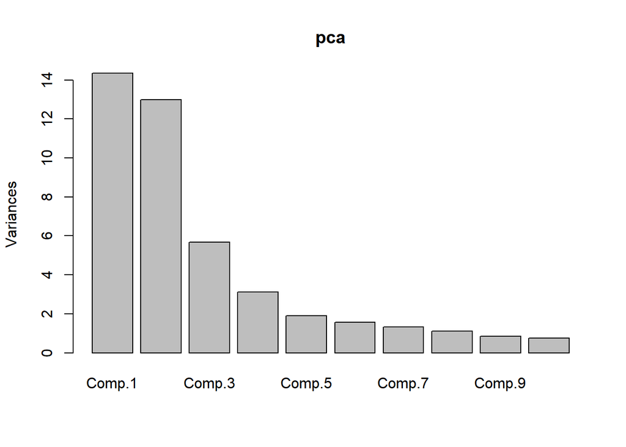

```r
## tranformation
catwalk[,c(5:21)]<-log(catwalk[,c(5:21)])
catwalk[,c(39:49)]<- logit( (catwalk[,c(39:49)]/100) +0.01)

## scaling
catwalk[,5:53]<-scale(catwalk[,5:53])

## getting principal components and % explained variance
pca<-princomp(catwalk[,5:53])
plot(pca)
```

```r
round( ((pca$sdev**2)/sum(pca$sdev**2)),3)
```

```
 Comp.1  Comp.2  Comp.3  Comp.4  Comp.5  Comp.6  Comp.7  Comp.8  Comp.9 Comp.10
  0.297   0.268   0.117   0.064   0.039   0.032   0.027   0.023   0.018   0.016
Comp.11 Comp.12 Comp.13 Comp.14 Comp.15 Comp.16 Comp.17 Comp.18 Comp.19 Comp.20
  0.015   0.013   0.011   0.008   0.007   0.005   0.005   0.004   0.004   0.004
Comp.21 Comp.22 Comp.23 Comp.24 Comp.25 Comp.26 Comp.27 Comp.28 Comp.29 Comp.30
  0.003   0.003   0.002   0.002   0.002   0.002   0.001   0.001   0.001   0.001
Comp.31 Comp.32 Comp.33 Comp.34 Comp.35 Comp.36 Comp.37 Comp.38 Comp.39 Comp.40
  0.001   0.001   0.001   0.001   0.000   0.000   0.000   0.000   0.000   0.000
Comp.41 Comp.42 Comp.43 Comp.44 Comp.45 Comp.46 Comp.47 Comp.48 Comp.49
  0.000   0.000   0.000   0.000   0.000   0.000   0.000   0.000   0.000
```

```r
sum( round( ((pca$sdev**2)/sum(pca$sdev**2)),3) [1:3])
```

```
[1] 0.682
```

```r
## extraction the PCs as another variables
catwalk$pca1<- c(scale(pca$scores[,1]))
catwalk$pca2<- c(scale(pca$scores[,2]))
catwalk$pca3<- c(scale(pca$scores[,3]))
```

3 principal components represent majority of variability in data of gait

## 2.1 data exploration

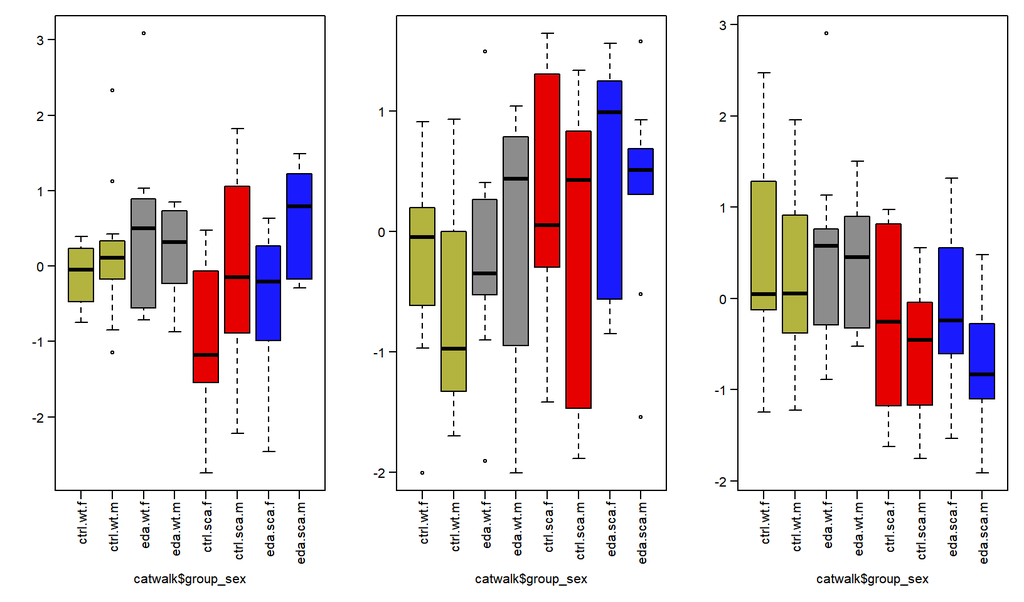

```r
## setting spacing
par(mar=c(7,3.5,1,1))
par(mgp=c(5,0.7,0))
par(mfrow = c(1,3))

## plotting values of the 3 main PCs across groups
plot(catwalk$pca1~catwalk$group_sex,
     col=cola[c(1,1,2,2,3,3,4,4)], las=2)
plot(catwalk$pca2~catwalk$group_sex,
     col=cola[c(1,1,2,2,3,3,4,4)], las=2)
plot(catwalk$pca3~catwalk$group_sex,
     col=cola[c(1,1,2,2,3,3,4,4)], las=2)
```

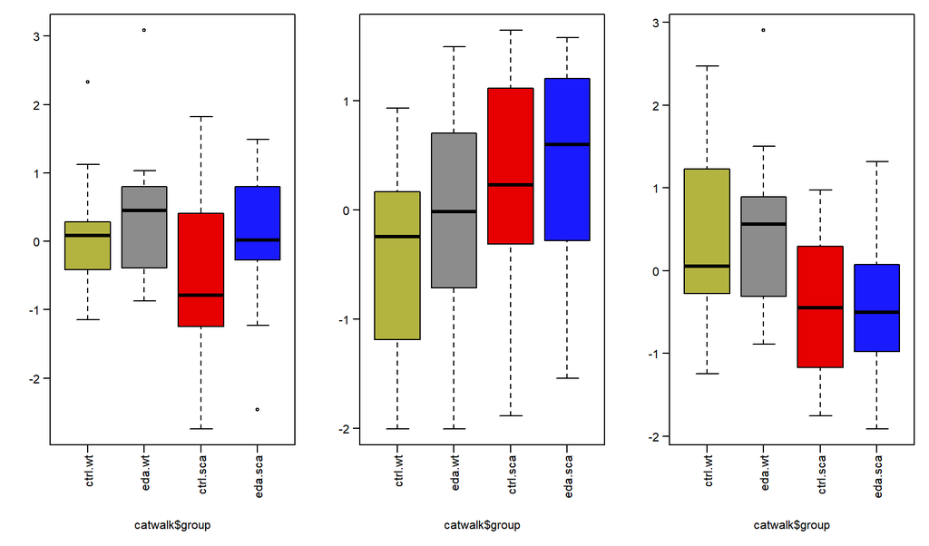

```r
par(mfrow = c(1, 3))
plot(catwalk$pca1~catwalk$group,col=cola, las=2)
plot(catwalk$pca2~catwalk$group,col=cola, las=2)
plot(catwalk$pca3~catwalk$group,col=cola, las=2)
```

Integration of PCs score to general table and assessing their correlations with individual gait parameters

```r
## Extraction
behav$walk_pc1<- c(scale(pca$scores[,1]))
behav$walk_pc2<- c(scale(pca$scores[,2]))
behav$walk_pc3<- c(scale(pca$scores[,3]))


## Correlation of PCs with gait parameters
cor1<-c(cor(catwalk$pca1,catwalk[,5:53],method="pearson"))
cor2<-c(cor(catwalk$pca2,catwalk[,5:53],method="pearson"))
cor3<-c(cor(catwalk$pca3,catwalk[,5:53],method="pearson"))


pc_gait_cor<-data.frame(cbind(names(catwalk[,5:53]),
                              cor1,cor2,cor3))
pc_gait_cor$cor1<-as.numeric(pc_gait_cor$cor1)
pc_gait_cor$cor2<-as.numeric(pc_gait_cor$cor2)
pc_gait_cor$cor3<-as.numeric(pc_gait_cor$cor3)

pc_gait_cor<-data.frame(parameter = pc_gait_cor$V1,
PC1_cor = cor1,
PC2_cor = cor2,
PC3_cor = cor3)

## Correlations of all axes with all parameters
knitr::kable(pc_gait_cor)
```

| parameter | PC1_cor | PC2_cor | PC3_cor |
| --- | --- | --- | --- |
| Run_Average_Speed_.cm.s._SD | 0.2672053 | 0.6095708 | 0.3561662 |
| RF_Stand_.s._SD | -0.6625579 | 0.6548039 | 0.1116333 |
| RF_Swing_.s._SD | -0.4970953 | 0.5323204 | 0.4379428 |
| RF_SwingSpeed_.cm.s._SD | 0.2303728 | 0.8915512 | 0.1911648 |
| RF_StrideLength_.cm._SD | -0.1581137 | 0.8213267 | 0.2811808 |
| RH_Stand_.s._SD | -0.5495105 | 0.6637357 | 0.0013374 |
| RH_Swing_.s._SD | -0.5164171 | 0.6159595 | 0.2649329 |
| RH_SwingSpeed_.cm.s._SD | 0.2379274 | 0.8582441 | 0.2234228 |
| RH_StrideLength_.cm._SD | -0.1944708 | 0.7945607 | 0.3271262 |
| LF_Stand_.s._SD | -0.6342372 | 0.6517018 | 0.0938350 |
| LF_Swing_.s._SD | -0.4188181 | 0.5059832 | 0.5451368 |
| LF_SwingSpeed_.cm.s._SD | 0.1613490 | 0.8980204 | 0.1137190 |
| LF_StrideLength_.cm._SD | -0.2103648 | 0.7978682 | 0.3177006 |
| LH_Stand_.s._SD | -0.6582108 | 0.6496784 | -0.0457254 |
| LH_Swing_.s._SD | -0.3323126 | 0.6148714 | 0.4479048 |
| LH_SwingSpeed_.cm.s._SD | 0.2507938 | 0.8393571 | 0.0126718 |
| LH_StrideLength_.cm._SD | -0.0651910 | 0.7609980 | 0.4168295 |
| Run_Average_Speed_.cm.s._Mean | 0.9004667 | 0.3414745 | 0.1116079 |
| RF_Stand_.s._Mean | -0.9110190 | -0.1901959 | 0.0645795 |
| RF_Swing_.s._Mean | -0.5214467 | -0.6390176 | 0.4954172 |
| RF_SwingSpeed_.cm.s._Mean | 0.7708241 | 0.5397599 | -0.1303897 |
| RF_StrideLength_.cm._Mean | 0.7666779 | -0.2154543 | 0.3955947 |
| RH_Stand_.s._Mean | -0.7881435 | -0.1053852 | -0.0662461 |
| RH_Swing_.s._Mean | -0.6218096 | -0.4758645 | 0.4438371 |
| RH_SwingSpeed_.cm.s._Mean | 0.8066497 | 0.4620823 | -0.1070256 |
| RH_StrideLength_.cm._Mean | 0.7576182 | -0.1996631 | 0.3866716 |
| LF_Stand_.s._Mean | -0.9249427 | -0.1788519 | 0.0182499 |
| LF_Swing_.s._Mean | -0.4384682 | -0.6459233 | 0.5276477 |
| LF_SwingSpeed_.cm.s._Mean | 0.7461173 | 0.5609859 | -0.2107481 |
| LF_StrideLength_.cm._Mean | 0.7653601 | -0.2310794 | 0.3892210 |
| LH_Stand_.s._Mean | -0.8352683 | -0.0606679 | -0.1319910 |
| LH_Swing_.s._Mean | -0.5268990 | -0.5088357 | 0.5057004 |
| LH_SwingSpeed_.cm.s._Mean | 0.7775097 | 0.4774909 | -0.2267086 |
| LH_StrideLength_.cm._Mean | 0.7533525 | -0.1833291 | 0.4148233 |
| StepSequence_CA_… | 0.0991969 | -0.1318993 | 0.2078292 |
| StepSequence_CB_… | 0.3363822 | -0.1149716 | 0.3563170 |
| StepSequence_AA_… | 0.2104824 | -0.2899867 | 0.4769519 |
| StepSequence_AB_… | -0.3590790 | 0.2682774 | -0.5431625 |
| Support_Zero_… | 0.2829771 | 0.0144798 | 0.5997906 |
| Support_Single_… | 0.2402412 | -0.2521296 | 0.7595718 |
| Support_Diagonal_… | 0.4158972 | -0.5117275 | -0.2713623 |
| Support_Girdle_… | -0.2942092 | 0.1913824 | -0.1087525 |
| Support_Lateral_… | 0.0790337 | 0.1132000 | 0.4384725 |
| Support_Three_… | -0.5224694 | 0.4856310 | -0.5824357 |
| Support_Four_… | -0.4867327 | 0.5440529 | -0.3823720 |
| BOS_FrontPaws_Mean_.cm. | -0.0516410 | 0.0871550 | -0.0738046 |
| BOS_HindPaws_Mean_.cm. | -0.0957587 | -0.5028307 | 0.1940434 |
| PrintPositions_RightPaws_Mean_.cm. | -0.6804820 | -0.2246993 | 0.1745176 |
| PrintPositions_LeftPaws_Mean_.cm. | -0.6513525 | -0.2344030 | 0.1784472 |

```r
## correlates of PC1
knitr::kable(pc_gait_cor[abs(pc_gait_cor$PC1_cor)>0.75,])
```

|  | parameter | PC1_cor | PC2_cor | PC3_cor |
| --- | --- | --- | --- | --- |
| 18 | Run_Average_Speed_.cm.s._Mean | 0.9004667 | 0.3414745 | 0.1116079 |
| 19 | RF_Stand_.s._Mean | -0.9110190 | -0.1901959 | 0.0645795 |
| 21 | RF_SwingSpeed_.cm.s._Mean | 0.7708241 | 0.5397599 | -0.1303897 |
| 22 | RF_StrideLength_.cm._Mean | 0.7666779 | -0.2154543 | 0.3955947 |
| 23 | RH_Stand_.s._Mean | -0.7881435 | -0.1053852 | -0.0662461 |
| 25 | RH_SwingSpeed_.cm.s._Mean | 0.8066497 | 0.4620823 | -0.1070256 |
| 26 | RH_StrideLength_.cm._Mean | 0.7576182 | -0.1996631 | 0.3866716 |
| 27 | LF_Stand_.s._Mean | -0.9249427 | -0.1788519 | 0.0182499 |
| 30 | LF_StrideLength_.cm._Mean | 0.7653601 | -0.2310794 | 0.3892210 |
| 31 | LH_Stand_.s._Mean | -0.8352683 | -0.0606679 | -0.1319910 |
| 33 | LH_SwingSpeed_.cm.s._Mean | 0.7775097 | 0.4774909 | -0.2267086 |
| 34 | LH_StrideLength_.cm._Mean | 0.7533525 | -0.1833291 | 0.4148233 |

```r
## Correlates of PC2
knitr::kable(pc_gait_cor[abs(pc_gait_cor$PC2_cor)>0.75,])
```

|  | parameter | PC1_cor | PC2_cor | PC3_cor |
| --- | --- | --- | --- | --- |
| 4 | RF_SwingSpeed_.cm.s._SD | 0.2303728 | 0.8915512 | 0.1911648 |
| 5 | RF_StrideLength_.cm._SD | -0.1581137 | 0.8213267 | 0.2811808 |
| 8 | RH_SwingSpeed_.cm.s._SD | 0.2379274 | 0.8582441 | 0.2234228 |
| 9 | RH_StrideLength_.cm._SD | -0.1944708 | 0.7945607 | 0.3271262 |
| 12 | LF_SwingSpeed_.cm.s._SD | 0.1613490 | 0.8980204 | 0.1137190 |
| 13 | LF_StrideLength_.cm._SD | -0.2103648 | 0.7978682 | 0.3177006 |
| 16 | LH_SwingSpeed_.cm.s._SD | 0.2507938 | 0.8393571 | 0.0126718 |
| 17 | LH_StrideLength_.cm._SD | -0.0651910 | 0.7609980 | 0.4168295 |

```r
## correlates of PC3
knitr::kable(pc_gait_cor[abs(pc_gait_cor$PC3_cor)>0.55,])
```

|  | parameter | PC1_cor | PC2_cor | PC3_cor |
| --- | --- | --- | --- | --- |
| 39 | Support_Zero_… | 0.2829771 | 0.0144798 | 0.5997906 |
| 40 | Support_Single_… | 0.2402412 | -0.2521296 | 0.7595718 |
| 44 | Support_Three_… | -0.5224694 | 0.4856310 | -0.5824357 |

# 3 Modelling

Statistical analysis will consist from 2 parts:

- 1. Multivariate analysis in frequentist framework, using PERMANOVA
- 2. Bayesian multivariate regression

1st part will assees which groups differed ‘statistically significanlty’ in terms of conglomerate of all parameters

2nd part will employ Bayesian regression and will estimate how much the groups differ in terms of the three main principal components (PCs explaining together majority of variance in the gait data)

As the overall structure of gait is affected by walk speed (which differ between WT and SCA1 mice, but also differ substatially from animal to animal), the 2nd analysis will be also validated with fitting same model but adjusted for speed (walk speed will be included as a covariate)

## 3.1 PERMANOVA

```r
## defining outcome
outcome <- catwalk[,5:53]

## PERMANOVA, all groups
if(file.exists('perm_all') == FALSE){
perm_all <- adonis2(outcome ~ group, data=catwalk, perm=999,method="euclidian")}
perm_all
```

```
Permutation test for adonis under reduced model
Terms added sequentially (first to last)
Permutation: free
Number of permutations: 999

adonis2(formula = outcome ~ group, data = catwalk, permutations = 999, method = "euclidian")
         Df SumOfSqs      R2      F Pr(>F)
group     3      376 0.09712 2.7251  0.002 **
Residual 76     3495 0.90288
Total    79     3871 1.00000
---
Signif. codes:  0 '***' 0.001 '**' 0.01 '*' 0.05 '.' 0.1 ' ' 1
```

```r
### edaravon in SCA1
catwalk_sca<-subset(catwalk,catwalk$group=="ctrl.sca"|catwalk$group=="eda.sca")
outcome<-catwalk_sca[,5:53]
if(file.exists('perm_sca1') == FALSE){
perm_sca1 <- adonis2(outcome ~ group, data=catwalk_sca, perm=99999,method="euclidian") }
perm_sca1
```

```
Permutation test for adonis under reduced model
Terms added sequentially (first to last)
Permutation: free
Number of permutations: 99999

adonis2(formula = outcome ~ group, data = catwalk_sca, permutations = 99999, method = "euclidian")
         Df SumOfSqs      R2      F Pr(>F)
group     1    70.69 0.03463 1.3631 0.2203
Residual 38  1970.74 0.96537
Total    39  2041.43 1.00000
```

```r
### edaravon in WT -
catwalk_wt<-subset(catwalk,catwalk$group=="eda.wt"|catwalk$group=="ctrl.wt")
outcome<-catwalk_wt[,5:53]

if(file.exists('perm_wt') == FALSE){
perm_wt <- adonis2(outcome ~ group, data=catwalk_wt, perm=9999,method="euclidian") }
perm_wt
```

```
Permutation test for adonis under reduced model
Terms added sequentially (first to last)
Permutation: free
Number of permutations: 9999

adonis2(formula = outcome ~ group, data = catwalk_wt, permutations = 9999, method = "euclidian")
         Df SumOfSqs      R2      F Pr(>F)
group     1    38.24 0.02447 0.9532 0.4241
Residual 38  1524.30 0.97553
Total    39  1562.54 1.00000
```

```r
### geenotype in ctrl
set.seed(17)
catwalk_ctrl<-subset(catwalk,catwalk$group=="ctrl.sca"|catwalk$group=="ctrl.wt")
outcome<-catwalk_ctrl[,5:53]

if(file.exists('perm_ctrl') == FALSE){
perm_ctrl <- adonis2(outcome ~ group, data=catwalk_sca, perm=9999,method="euclidian")}
perm_ctrl
```

```
Permutation test for adonis under reduced model
Terms added sequentially (first to last)
Permutation: free
Number of permutations: 9999

adonis2(formula = outcome ~ group, data = catwalk_sca, permutations = 9999, method = "euclidian")
         Df SumOfSqs      R2      F Pr(>F)
group     1   123.51 0.06211 2.5167 0.0303 *
Residual 38  1864.97 0.93789
Total    39  1988.49 1.00000
---
Signif. codes:  0 '***' 0.001 '**' 0.01 '*' 0.05 '.' 0.1 ' ' 1
```

As seen, groups generally differ, with ‘significant’ difference between WT and SCA1 mice on saline. Edaravone treatment does not seem to have effect.

## 3.2 Bayesian models - without speed adjustment

### 3.2.1 Priors and formulas

```r
## re-setting reference levels and creating new variable
behav$group <- relevel(behav$group,ref='ctrl.sca')
behav$speed <- scale(behav$Run_Average_Speed_.cm.s._Mean)

## formula
bf_pc1<-bf(walk_pc1~0+Intercept+group)
bf_pc2<-bf(walk_pc2~0+Intercept+group)
bf_pc3<-bf(walk_pc3~0+Intercept+group)

## prior
prior_1 <- get_prior(bf_pc1+bf_pc2+bf_pc3+
                      set_rescor(TRUE), data = behav,family=gaussian())
prior_1
```

```
                prior  class         coef group    resp dpar nlpar lb ub
               (flat)      b
               lkj(1) rescor
               (flat)      b                    walkpc1
               (flat)      b groupctrl.wt       walkpc1
               (flat)      b groupeda.sca       walkpc1
               (flat)      b  groupeda.wt       walkpc1
               (flat)      b    Intercept       walkpc1
 student_t(3, 0, 2.5)  sigma                    walkpc1             0
               (flat)      b                    walkpc2
               (flat)      b groupctrl.wt       walkpc2
               (flat)      b groupeda.sca       walkpc2
               (flat)      b  groupeda.wt       walkpc2
               (flat)      b    Intercept       walkpc2
 student_t(3, 0, 2.5)  sigma                    walkpc2             0
               (flat)      b                    walkpc3
               (flat)      b groupctrl.wt       walkpc3
               (flat)      b groupeda.sca       walkpc3
               (flat)      b  groupeda.wt       walkpc3
               (flat)      b    Intercept       walkpc3
 student_t(3, 0, 2.5)  sigma                    walkpc3             0
       source
      default
      default
      default
 (vectorized)
 (vectorized)
 (vectorized)
 (vectorized)
      default
      default
 (vectorized)
 (vectorized)
 (vectorized)
 (vectorized)
      default
      default
 (vectorized)
 (vectorized)
 (vectorized)
 (vectorized)
      default
```

```r
prior_1$prior[c(4,6,10,12,16,18)]<-"normal(0,2)"
prior_1$prior[c(5,11,17)]<-"normal(0,1.2)"
prior_1$prior[c(7,13,19)]<-"student_t(3,0,5)"
```

### 3.2.2 Model fit and diagnostics

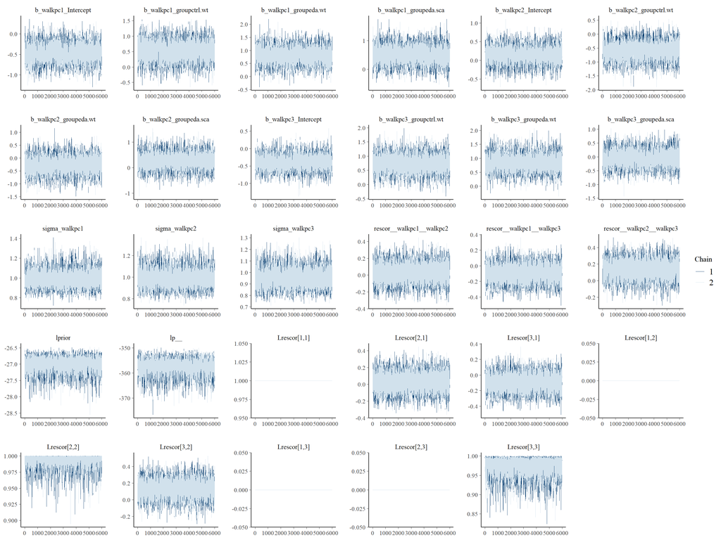

```r
## without adjustment for speed
set.seed(17)
pc_mult1 <- run_model(
          brm(bf_pc1+bf_pc2+bf_pc3
              +set_rescor(TRUE),
              data=behav, prior = prior_1,
              family=gaussian(),
              save_pars = save_pars(all = TRUE),
              iter=8000, warmup=2000,chains=2,cores=1,seed=17,
              control = list(adapt_delta = 0.99)),
              'output/brm/pc_mult1', reuse = TRUE)

mcmc_trace(pc_mult1)
```

```r
summary(pc_mult1)
```

```
 Family: MV(gaussian, gaussian, gaussian)
  Links: mu = identity; sigma = identity
         mu = identity; sigma = identity
         mu = identity; sigma = identity
Formula: walk_pc1 ~ 0 + Intercept + group
         walk_pc2 ~ 0 + Intercept + group
         walk_pc3 ~ 0 + Intercept + group
   Data: behav (Number of observations: 80)
  Draws: 2 chains, each with iter = 8000; warmup = 2000; thin = 1;
         total post-warmup draws = 12000

Population-Level Effects:
                     Estimate Est.Error l-95% CI u-95% CI Rhat Bulk_ESS
walkpc1_Intercept       -0.47      0.21    -0.89    -0.04 1.00     6796
walkpc1_groupctrl.wt     0.52      0.31    -0.08     1.12 1.00     8242
walkpc1_groupeda.wt      0.82      0.31     0.21     1.43 1.00     8474
walkpc1_groupeda.sca     0.53      0.30    -0.07     1.11 1.00     8149
walkpc2_Intercept        0.15      0.21    -0.28     0.57 1.00     5957
walkpc2_groupctrl.wt    -0.60      0.30    -1.20     0.00 1.00     7397
walkpc2_groupeda.wt     -0.27      0.31    -0.87     0.34 1.00     7407
walkpc2_groupeda.sca     0.27      0.29    -0.31     0.85 1.00     7705
walkpc3_Intercept       -0.39      0.21    -0.79     0.01 1.00     6349
walkpc3_groupctrl.wt     0.74      0.29     0.17     1.32 1.00     8287
walkpc3_groupeda.wt      0.85      0.29     0.27     1.42 1.00     8133
walkpc3_groupeda.sca    -0.05      0.29    -0.61     0.52 1.00     8158
                     Tail_ESS
walkpc1_Intercept        7958
walkpc1_groupctrl.wt     8608
walkpc1_groupeda.wt      8339
walkpc1_groupeda.sca     8095
walkpc2_Intercept        6609
walkpc2_groupctrl.wt     8175
walkpc2_groupeda.wt      7616
walkpc2_groupeda.sca     8570
walkpc3_Intercept        7940
walkpc3_groupctrl.wt     8642
walkpc3_groupeda.wt      7921
walkpc3_groupeda.sca     8638

Family Specific Parameters:
              Estimate Est.Error l-95% CI u-95% CI Rhat Bulk_ESS Tail_ESS
sigma_walkpc1     0.99      0.08     0.85     1.17 1.00    13278     8666
sigma_walkpc2     0.99      0.08     0.84     1.17 1.00    13803     7693
sigma_walkpc3     0.95      0.08     0.81     1.12 1.00    14664     8168

Residual Correlations:
                        Estimate Est.Error l-95% CI u-95% CI Rhat Bulk_ESS
rescor(walkpc1,walkpc2)     0.03      0.11    -0.19     0.26 1.00    12091
rescor(walkpc1,walkpc3)    -0.10      0.11    -0.31     0.12 1.00    12416
rescor(walkpc2,walkpc3)     0.13      0.11    -0.09     0.34 1.00    11722
                        Tail_ESS
rescor(walkpc1,walkpc2)     8352
rescor(walkpc1,walkpc3)     8543
rescor(walkpc2,walkpc3)     8247

Draws were sampled using sampling(NUTS). For each parameter, Bulk_ESS
and Tail_ESS are effective sample size measures, and Rhat is the potential
scale reduction factor on split chains (at convergence, Rhat = 1).
```

Convergence is fine

## 3.3 Bayesian model with speed adjustment

### 3.3.1 formula and prior

```r
bf_adj_pc1<-bf(walk_pc1~0+Intercept+group+s(speed,k=3))
bf_adj_pc2<-bf(walk_pc2~0+Intercept+group+s(speed,k=3))
bf_adj_pc3<-bf(walk_pc3~0+Intercept+group+s(speed,k=3))


prior_2 <- get_prior(bf_adj_pc1+bf_adj_pc2+bf_adj_pc3+
                       set_rescor(TRUE), data = behav,family=gaussian())
prior_2
```

```
                prior  class            coef group    resp dpar nlpar lb ub
               (flat)      b
               lkj(1) rescor
               (flat)      b                       walkpc1
               (flat)      b    groupctrl.wt       walkpc1
               (flat)      b    groupeda.sca       walkpc1
               (flat)      b     groupeda.wt       walkpc1
               (flat)      b       Intercept       walkpc1
               (flat)      b        sspeed_1       walkpc1
 student_t(3, 0, 2.5)    sds                       walkpc1             0
 student_t(3, 0, 2.5)    sds s(speed, k = 3)       walkpc1             0
 student_t(3, 0, 2.5)  sigma                       walkpc1             0
               (flat)      b                       walkpc2
               (flat)      b    groupctrl.wt       walkpc2
               (flat)      b    groupeda.sca       walkpc2
               (flat)      b     groupeda.wt       walkpc2
               (flat)      b       Intercept       walkpc2
               (flat)      b        sspeed_1       walkpc2
 student_t(3, 0, 2.5)    sds                       walkpc2             0
 student_t(3, 0, 2.5)    sds s(speed, k = 3)       walkpc2             0
 student_t(3, 0, 2.5)  sigma                       walkpc2             0
               (flat)      b                       walkpc3
               (flat)      b    groupctrl.wt       walkpc3
               (flat)      b    groupeda.sca       walkpc3
               (flat)      b     groupeda.wt       walkpc3
               (flat)      b       Intercept       walkpc3
               (flat)      b        sspeed_1       walkpc3
 student_t(3, 0, 2.5)    sds                       walkpc3             0
 student_t(3, 0, 2.5)    sds s(speed, k = 3)       walkpc3             0
 student_t(3, 0, 2.5)  sigma                       walkpc3             0
       source
      default
      default
      default
 (vectorized)
 (vectorized)
 (vectorized)
 (vectorized)
 (vectorized)
      default
 (vectorized)
      default
      default
 (vectorized)
 (vectorized)
 (vectorized)
 (vectorized)
 (vectorized)
      default
 (vectorized)
      default
      default
 (vectorized)
 (vectorized)
 (vectorized)
 (vectorized)
 (vectorized)
      default
 (vectorized)
      default
```

```r
prior_2$prior[c(4,6,13,15,22,24)]<-"normal(0,2)"
prior_2$prior[c(5,14,23)]<-"normal(0,1.2)"
prior_2$prior[c(7,16,25)]<-"student_t(3,0,5)"
prior_2$prior[c(8,17,26)]<-"normal(0,2)"
```

### 3.3.2 Model fit and diagnostics

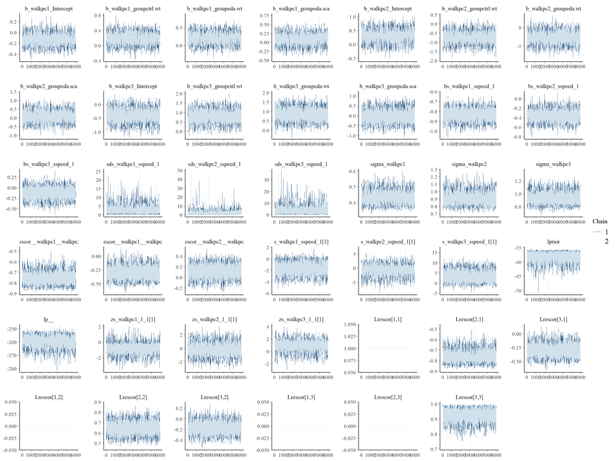

```r
pc_mult2 <- run_model(
          brm(bf_adj_pc1+bf_adj_pc2+bf_adj_pc3+
                   set_rescor(TRUE),
                 data=behav, prior = prior_2,
                 family=gaussian(),
                 save_pars = save_pars(all = TRUE),
                 iter=8000, warmup=2000,chains=2,cores=1,seed=17,
                 control = list(adapt_delta = 0.99)),
              'output/brm/pc_mult2', reuse = TRUE)

mcmc_trace(pc_mult2)
```

```r
summary(pc_mult2)
```

```
 Family: MV(gaussian, gaussian, gaussian)
  Links: mu = identity; sigma = identity
         mu = identity; sigma = identity
         mu = identity; sigma = identity
Formula: walk_pc1 ~ 0 + Intercept + group + s(speed, k = 3)
         walk_pc2 ~ 0 + Intercept + group + s(speed, k = 3)
         walk_pc3 ~ 0 + Intercept + group + s(speed, k = 3)
   Data: behav (Number of observations: 80)
  Draws: 2 chains, each with iter = 8000; warmup = 2000; thin = 1;
         total post-warmup draws = 12000

Smooth Terms:
                      Estimate Est.Error l-95% CI u-95% CI Rhat Bulk_ESS
sds(walkpc1_sspeed_1)     2.54      2.00     0.22     7.67 1.00     6258
sds(walkpc2_sspeed_1)     2.05      2.15     0.07     6.96 1.00     7763
sds(walkpc3_sspeed_1)     3.46      2.86     0.18    10.66 1.00     6619
                      Tail_ESS
sds(walkpc1_sspeed_1)     4523
sds(walkpc2_sspeed_1)     4351
sds(walkpc3_sspeed_1)     4665

Population-Level Effects:
                     Estimate Est.Error l-95% CI u-95% CI Rhat Bulk_ESS
walkpc1_Intercept       -0.12      0.10    -0.32     0.07 1.00     3203
walkpc1_groupctrl.wt     0.19      0.14    -0.08     0.46 1.00     3848
walkpc1_groupeda.wt      0.21      0.14    -0.06     0.49 1.00     3895
walkpc1_groupeda.sca     0.09      0.14    -0.18     0.36 1.00     3961
walkpc2_Intercept        0.29      0.20    -0.11     0.70 1.00     3466
walkpc2_groupctrl.wt    -0.74      0.29    -1.30    -0.17 1.00     4166
walkpc2_groupeda.wt     -0.52      0.29    -1.09     0.06 1.00     4378
walkpc2_groupeda.sca     0.09      0.29    -0.48     0.64 1.00     4130
walkpc3_Intercept       -0.40      0.21    -0.82     0.01 1.00     4993
walkpc3_groupctrl.wt     0.79      0.30     0.21     1.38 1.00     5664
walkpc3_groupeda.wt      0.85      0.30     0.27     1.44 1.00     6321
walkpc3_groupeda.sca    -0.02      0.29    -0.61     0.56 1.00     6383
walkpc1_sspeed_1        -0.84      0.06    -0.94    -0.73 1.00     7357
walkpc2_sspeed_1        -0.36      0.11    -0.58    -0.14 1.00     8563
walkpc3_sspeed_1        -0.13      0.12    -0.37     0.12 1.00    10248
                     Tail_ESS
walkpc1_Intercept        5802
```

[output cut: 19 more lines]

```
sigma_walkpc3     0.93      0.08     0.79     1.11 1.00    11531     8651

Residual Correlations:
                        Estimate Est.Error l-95% CI u-95% CI Rhat Bulk_ESS
rescor(walkpc1,walkpc2)    -0.76      0.05    -0.84    -0.65 1.00     8240
rescor(walkpc1,walkpc3)    -0.30      0.10    -0.49    -0.09 1.00    12339
rescor(walkpc2,walkpc3)     0.12      0.11    -0.11     0.33 1.00    12441
                        Tail_ESS
rescor(walkpc1,walkpc2)     8532
rescor(walkpc1,walkpc3)     8824
rescor(walkpc2,walkpc3)     8512

Draws were sampled using sampling(NUTS). For each parameter, Bulk_ESS
and Tail_ESS are effective sample size measures, and Rhat is the potential
scale reduction factor on split chains (at convergence, Rhat = 1).
```

Convergence is fine

### 3.3.3 PPC and models compariron

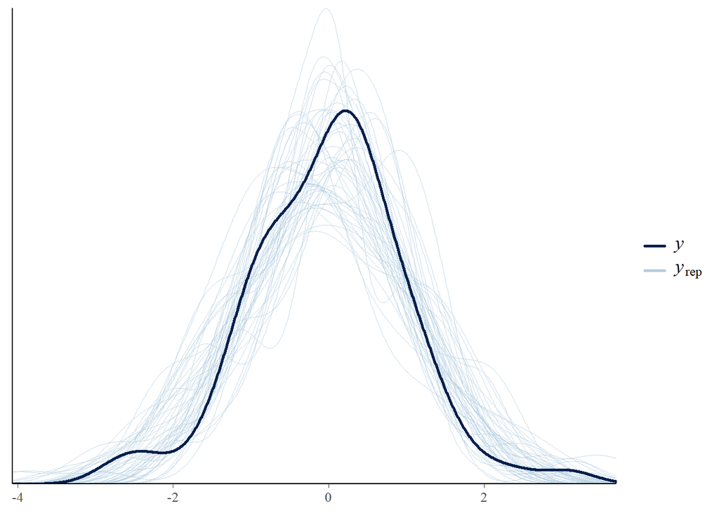

```r
### Bayesian checking - without speed
pp_check(pc_mult1,type='dens_overlay',ndraws = 50,resp="walkpc1")
```

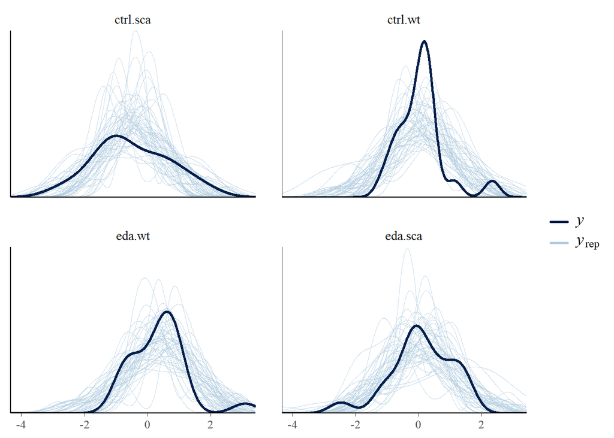

```r
pp_check(pc_mult1,type='dens_overlay_grouped',ndraws = 50,group='group',resp="walkpc1")
```

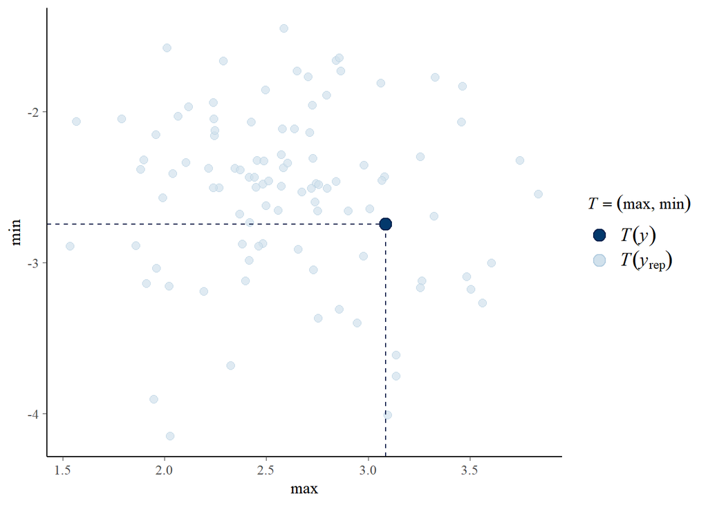

```r
pp_check(pc_mult1,type="stat_2d", stat = c("max", "min"),ndraws=100,resp="walkpc1")
```

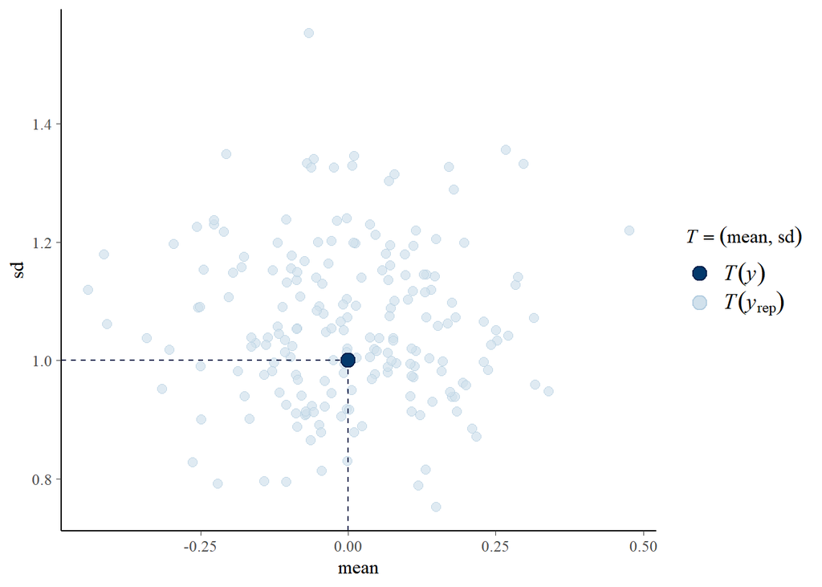

```r
pp_check(pc_mult1,type="stat_2d", stat = c("mean", "sd"),ndraws=200,resp="walkpc1")
```

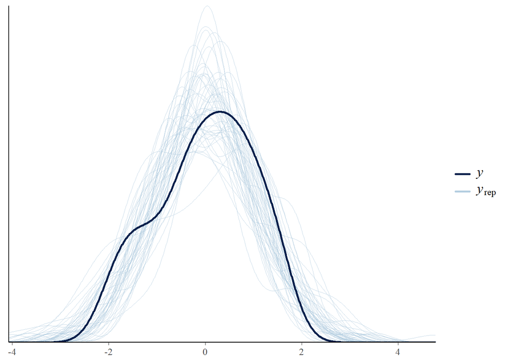

```r
pp_check(pc_mult1,type='dens_overlay',ndraws = 50,resp="walkpc2")
```

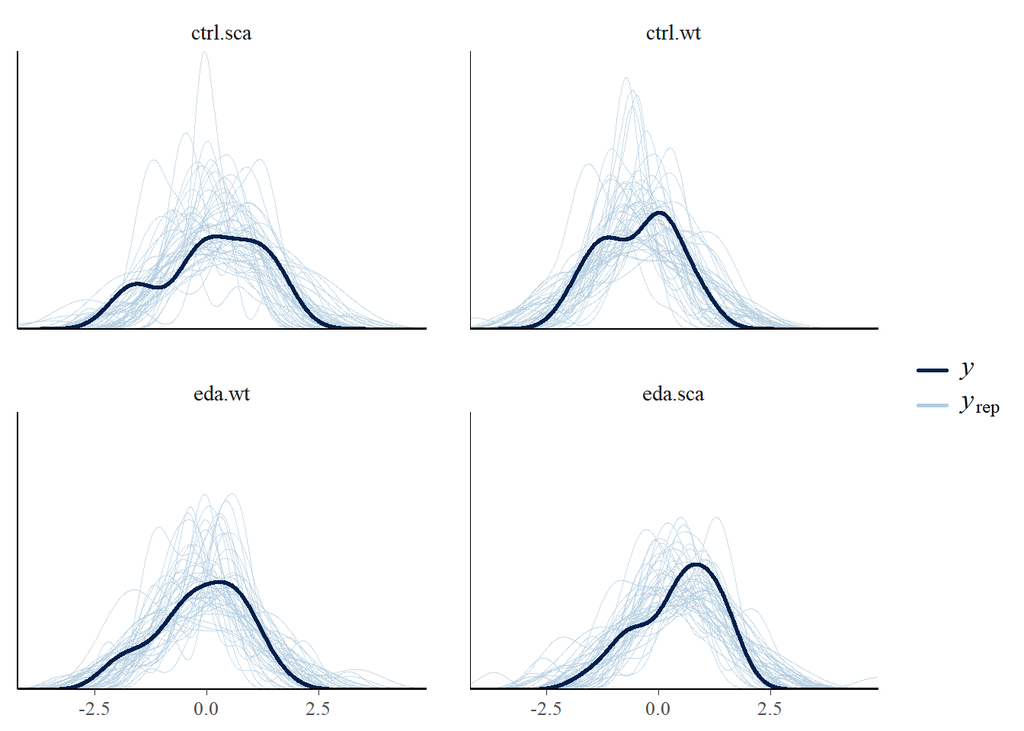

```r
pp_check(pc_mult1,type='dens_overlay_grouped',ndraws = 50,group='group',resp="walkpc2")
```

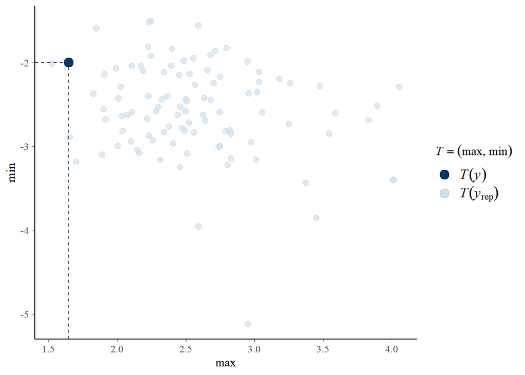

```r
pp_check(pc_mult1,type="stat_2d", stat = c("max", "min"),ndraws=100,resp="walkpc2")
```

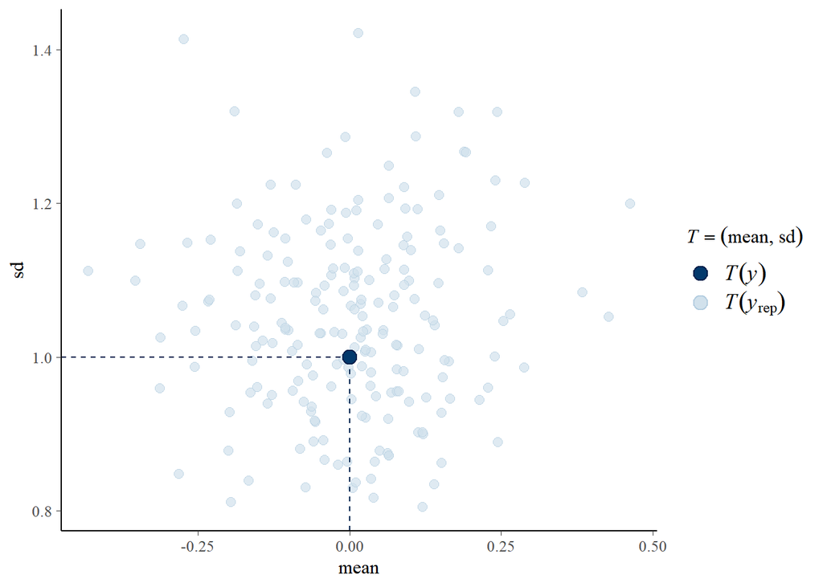

```r
pp_check(pc_mult1,type="stat_2d", stat = c("mean", "sd"),ndraws=200,resp="walkpc2")
```

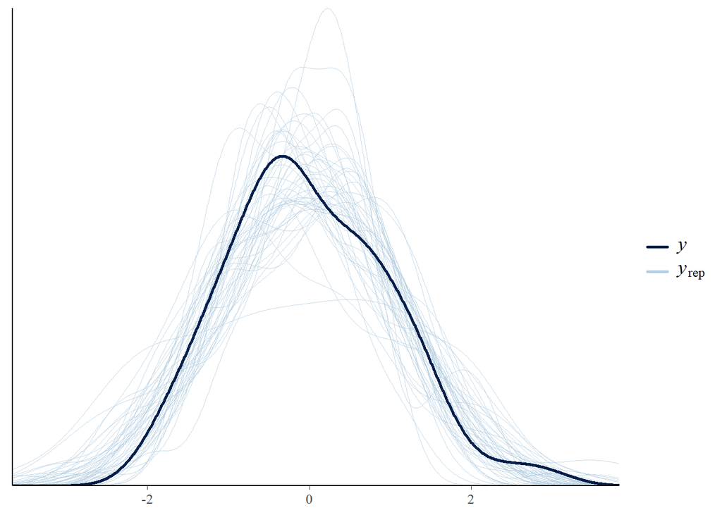

```r
pp_check(pc_mult1,type='dens_overlay',ndraws = 50,resp="walkpc3")
```

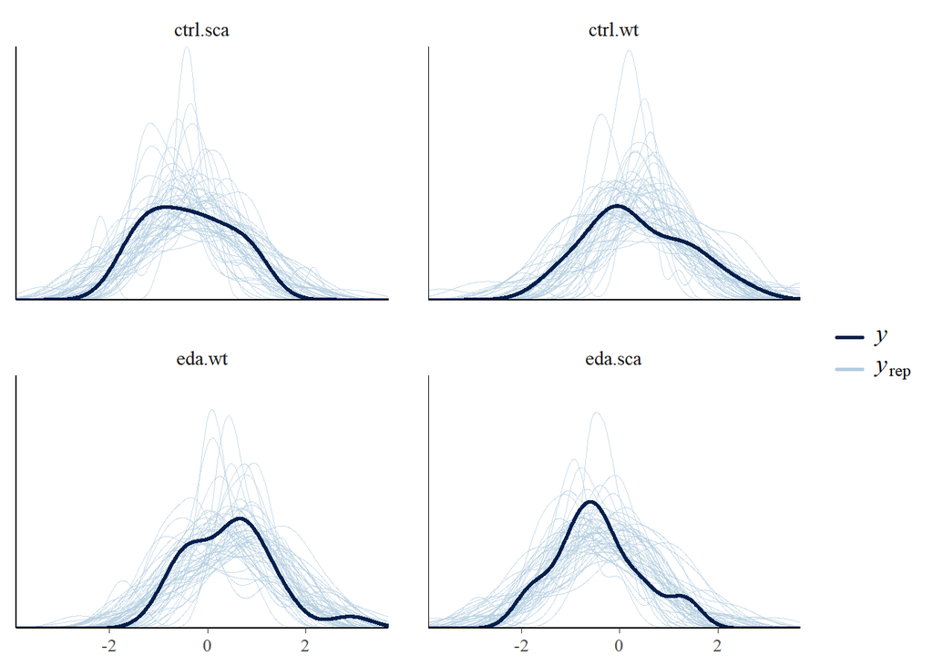

```r
pp_check(pc_mult1,type='dens_overlay_grouped',ndraws = 50,group='group',resp="walkpc3")
```

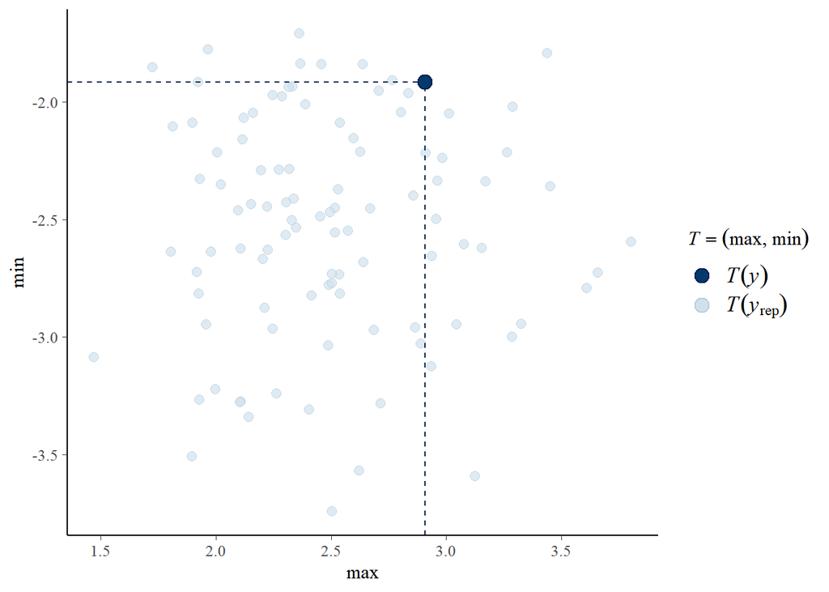

```r
pp_check(pc_mult1,type="stat_2d", stat = c("max", "min"),ndraws=100,resp="walkpc3")
```

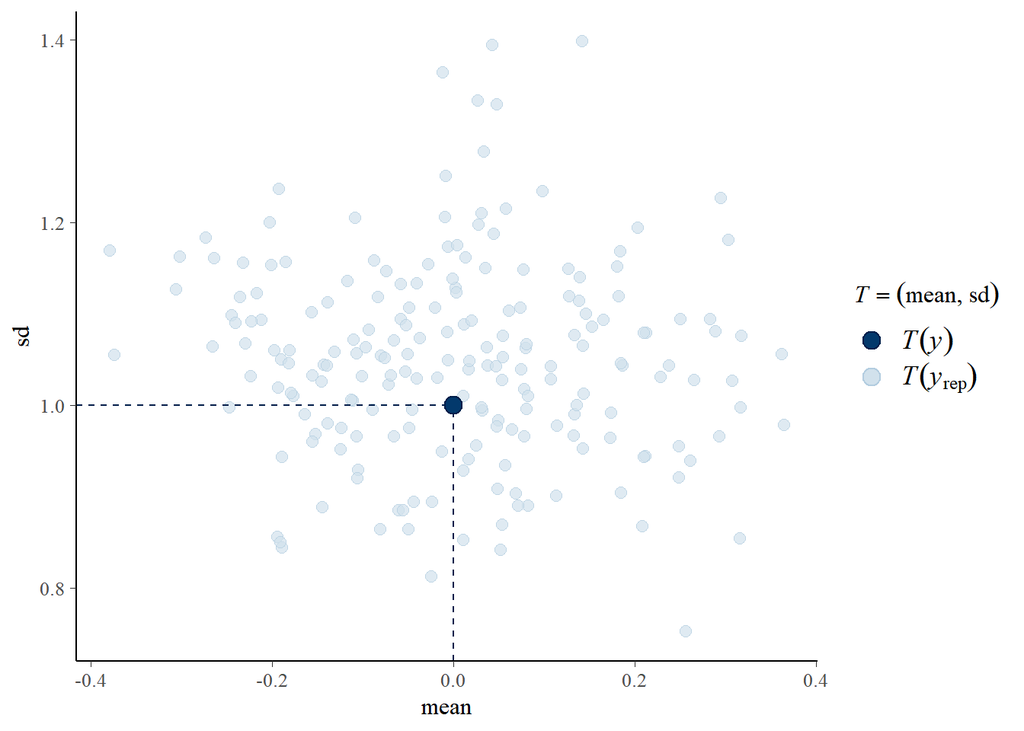

```r
pp_check(pc_mult1,type="stat_2d", stat = c("mean", "sd"),ndraws=200,resp="walkpc3")
```

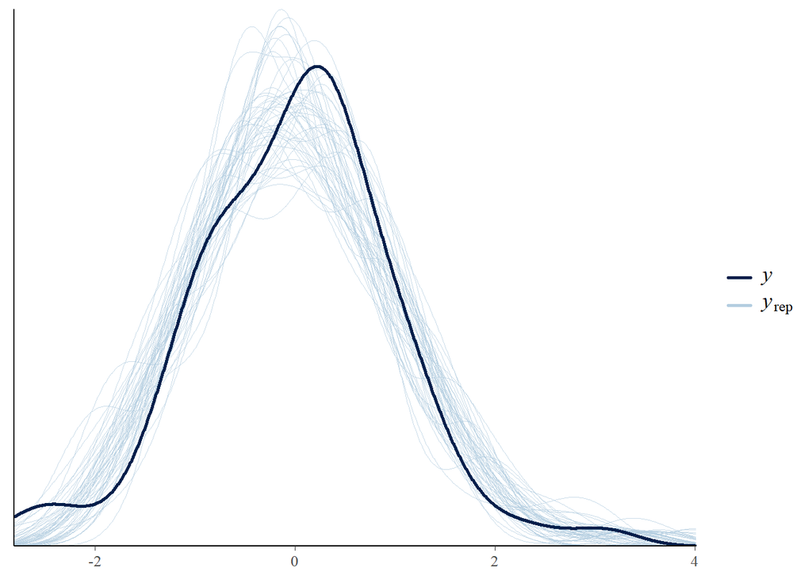

```r
### Bayesian checking -  speed included
pp_check(pc_mult2,type='dens_overlay',ndraws = 50,resp="walkpc1")
```

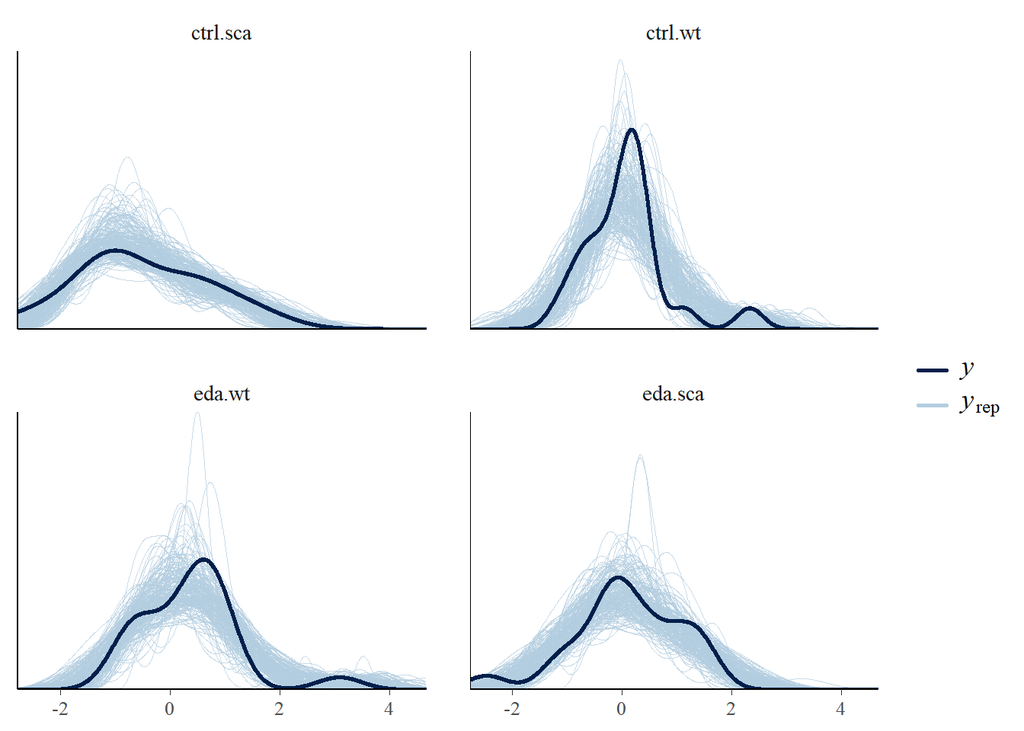

```r
pp_check(pc_mult2,type='dens_overlay_grouped',ndraws = 200,group='group',resp="walkpc1")
```

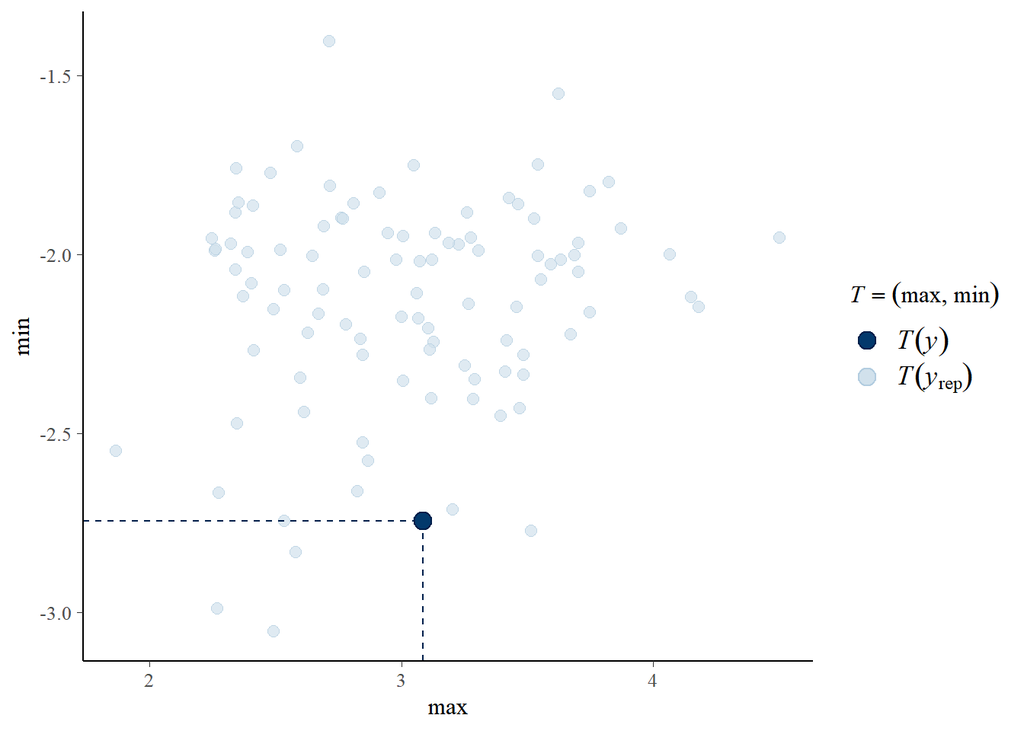

```r
pp_check(pc_mult2,type="stat_2d", stat = c("max", "min"),ndraws=100,resp="walkpc1")
```

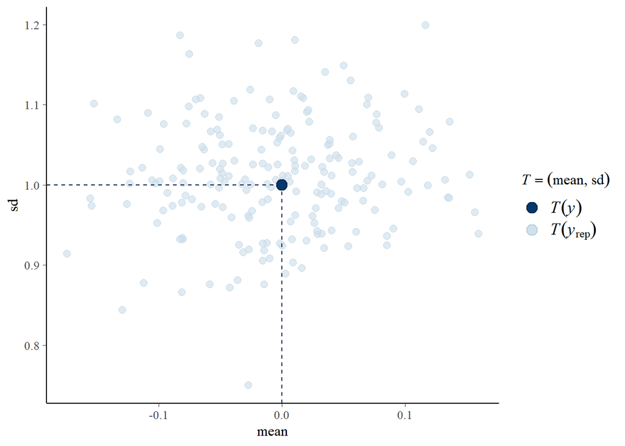

```r
pp_check(pc_mult2,type="stat_2d", stat = c("mean", "sd"),ndraws=200,resp="walkpc1")
```

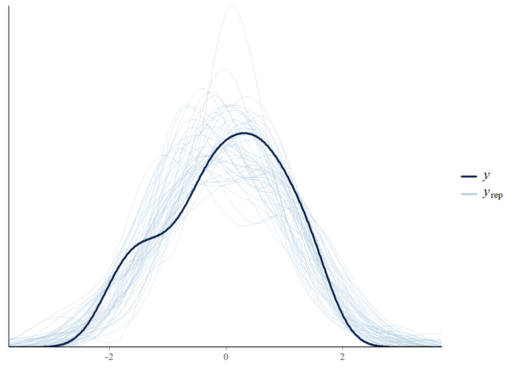

```r
pp_check(pc_mult2,type='dens_overlay',ndraws = 50,resp="walkpc2")
```

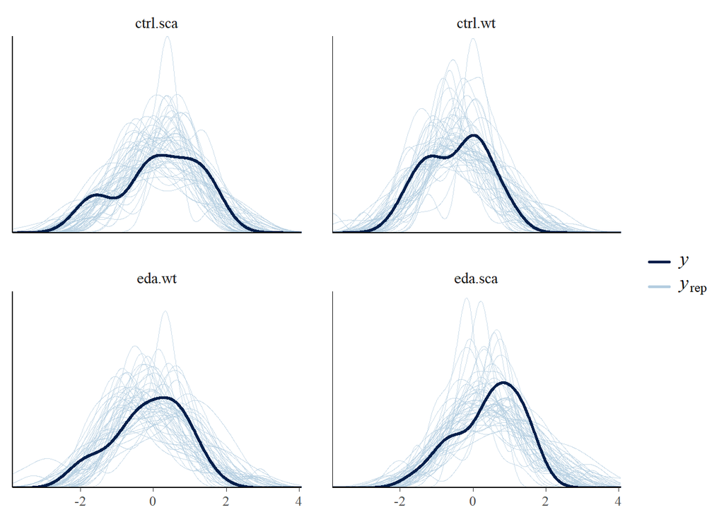

```r
pp_check(pc_mult2,type='dens_overlay_grouped',ndraws = 50,group='group',resp="walkpc2")
```

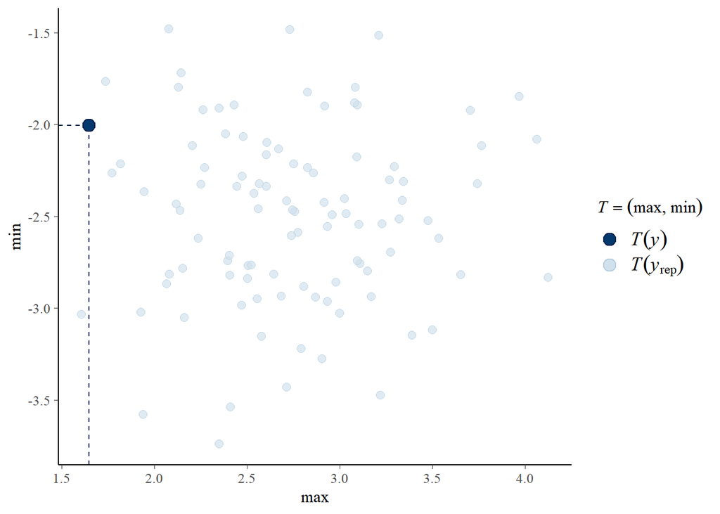

```r
pp_check(pc_mult2,type="stat_2d", stat = c("max", "min"),ndraws=100,resp="walkpc2")
```

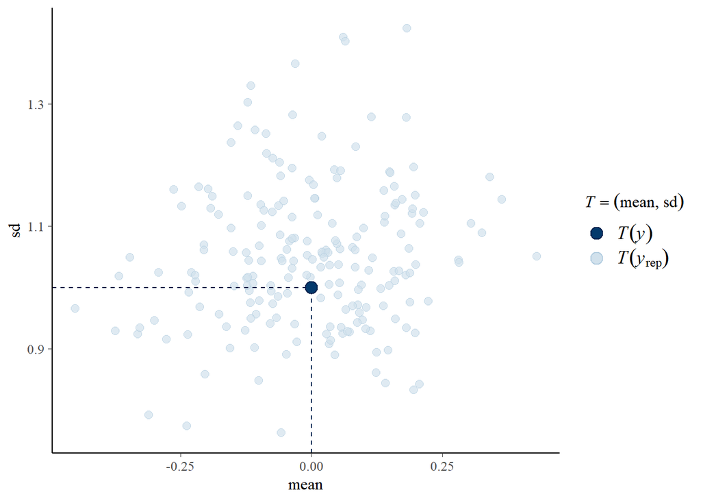

```r
pp_check(pc_mult2,type="stat_2d", stat = c("mean", "sd"),ndraws=200,resp="walkpc2")
```

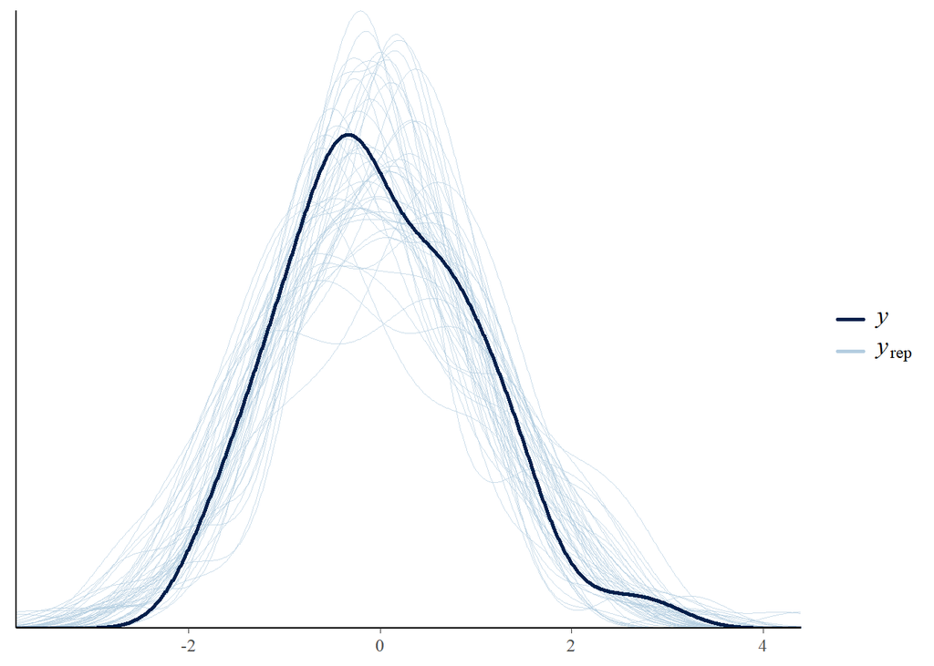

```r
pp_check(pc_mult2,type='dens_overlay',ndraws = 50,resp="walkpc3")
```

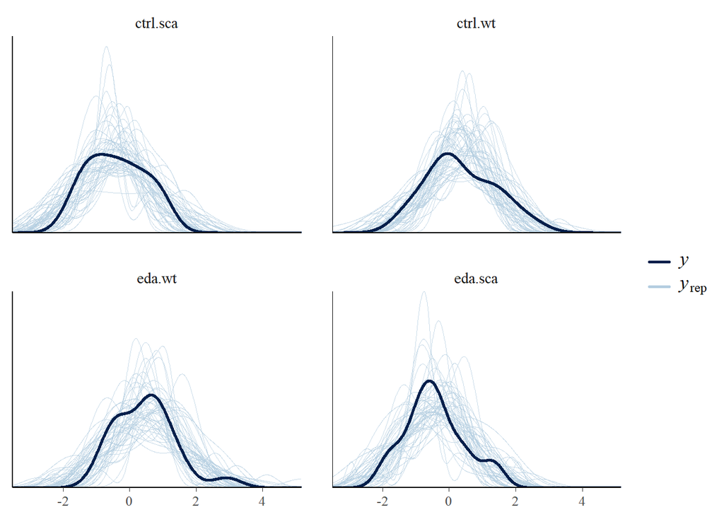

```r
pp_check(pc_mult2,type='dens_overlay_grouped',ndraws = 50,group='group',resp="walkpc3")
```

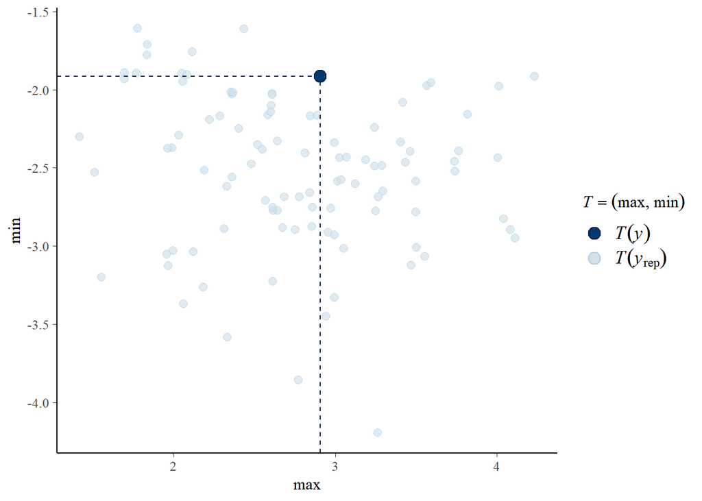

```r
pp_check(pc_mult2,type="stat_2d", stat = c("max", "min"),ndraws=100,resp="walkpc3")
```

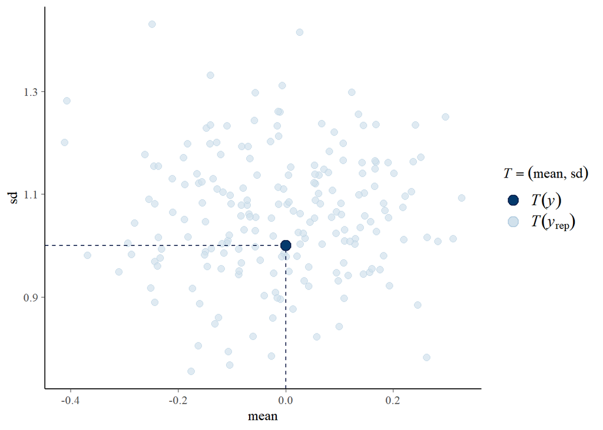

```r
pp_check(pc_mult2,type="stat_2d", stat = c("mean", "sd"),ndraws=200,resp="walkpc3")
```

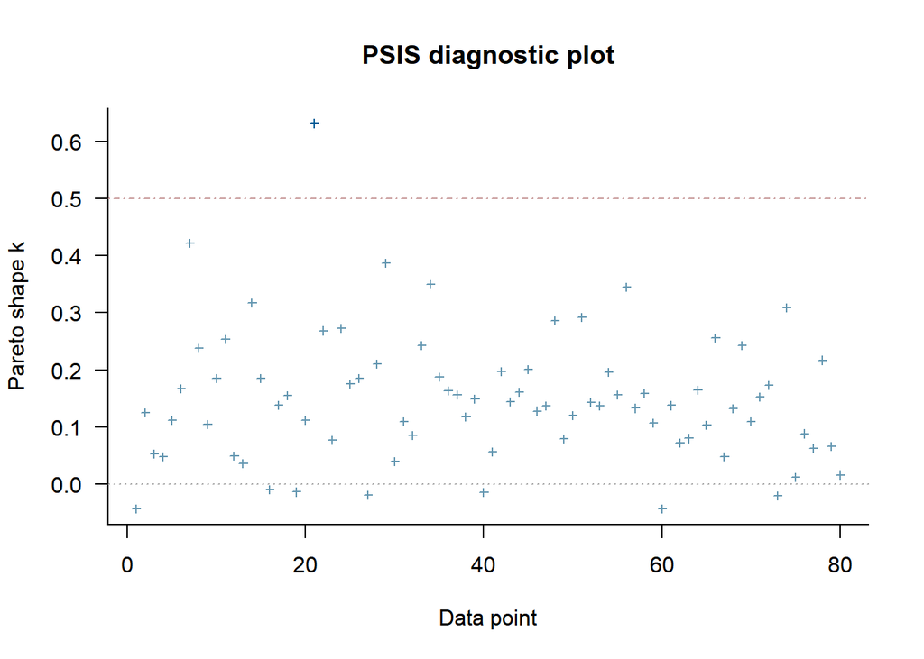

```
Computed from 12000 by 80 log-likelihood matrix

         Estimate   SE
elpd_loo   -339.9 12.8
p_loo        17.4  2.9
looic       679.8 25.5
------
Monte Carlo SE of elpd_loo is 0.1.

Pareto k diagnostic values:
                         Count Pct.    Min. n_eff
(-Inf, 0.5]   (good)     79    98.8%   2395
 (0.5, 0.7]   (ok)        1     1.2%   210
   (0.7, 1]   (bad)       0     0.0%   <NA>
   (1, Inf)   (very bad)  0     0.0%   <NA>

All Pareto k estimates are ok (k < 0.7).
See help('pareto-k-diagnostic') for details.
```

```r
plot(loo(pc_mult1));loo(pc_mult1)
```

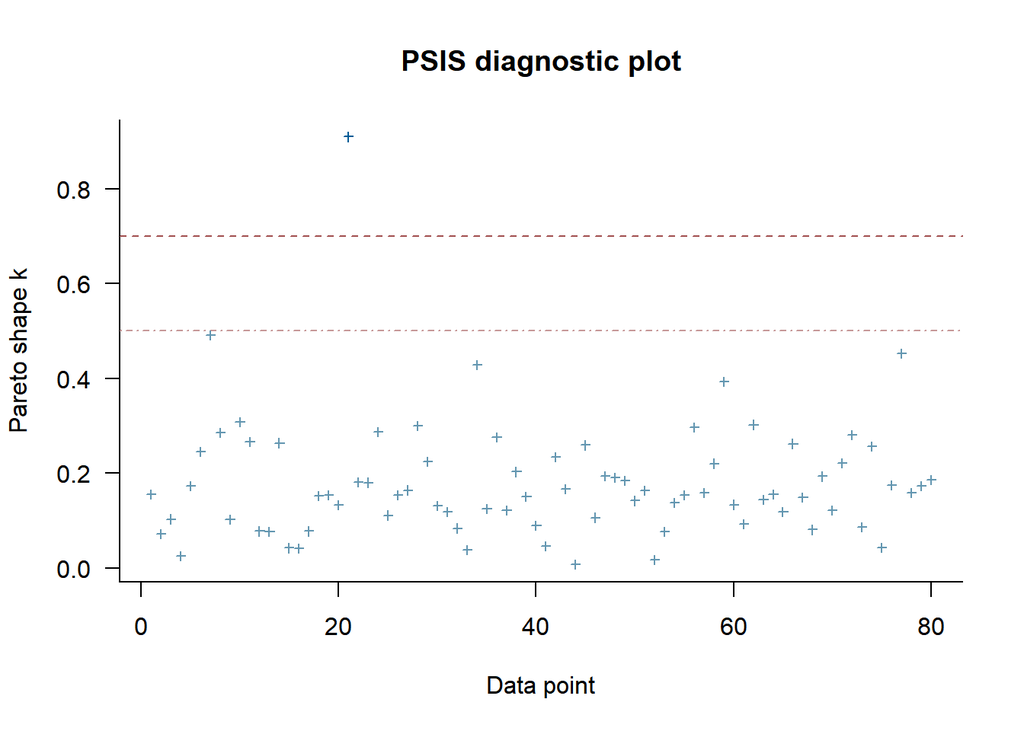

```
Computed from 12000 by 80 log-likelihood matrix

         Estimate   SE
elpd_loo   -230.0 11.2
p_loo        22.9  3.8
looic       459.9 22.5
------
Monte Carlo SE of elpd_loo is NA.

Pareto k diagnostic values:
                         Count Pct.    Min. n_eff
(-Inf, 0.5]   (good)     79    98.8%   1655
 (0.5, 0.7]   (ok)        0     0.0%   <NA>
   (0.7, 1]   (bad)       1     1.2%   68
   (1, Inf)   (very bad)  0     0.0%   <NA>
See help('pareto-k-diagnostic') for details.
```

```r
plot(loo(pc_mult2));loo(pc_mult2)
```

```r
### comparison of predictive ability via leave-one-out CV
pc_mult1 <- add_criterion(pc_mult1, criterion = "loo")
pc_mult2 <- add_criterion(pc_mult2, criterion = "loo")
loo_compare(pc_mult1,pc_mult2)
```

```
         elpd_diff se_diff
pc_mult2    0.0       0.0
pc_mult1 -109.9      10.3
```

Models are generally OK. Speed adjustment highly improves predictive accuracy of model.

# 4 Visualisation

## 4.1 PCA plot

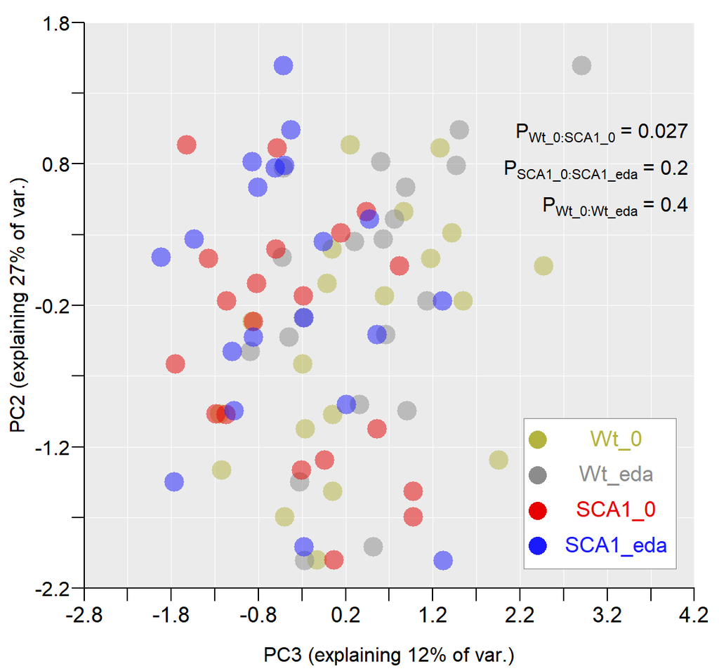

```r
## plotting multidimensional-------------
behav$group<-factor(behav$group,levels=c('ctrl.wt','eda.wt','ctrl.sca','eda.sca'))

par(mfrow=c(1,1))
par(mar=c(2.5,2.5,0,0))
par(mgp=c(1.3,0.6,0))
range<-c(-2.2,1.8);scal<-range[2]-range[1]
xrange<-c(-2.8,4.2);xscal=xrange[2]-xrange[1]

plot(NULL,xlim=c(xrange[1],xrange[2]),ylim=c(range[1],range[2]),
     xlab="PC3 (explaining 12% of var.)",
     ylab="PC2 (explaining 27% of var.)",
     las=1, axes=FALSE,cex.lab=1)

rect(xrange[1],range[2],xrange[2],range[1],col="grey92",border=NA)
x<-range[1]
repeat{
  lines(c(xrange[1],xrange[2]),c(x,x),col="white",lwd=0.7)
  x=x+0.5;if(x>range[2]){break}}

x<-xrange[1]
repeat{
  lines(c(x,x),c(range[1],range[2]),col="white",lwd=0.7)
  x=x+0.5;if(x>xrange[2]){break}}


x=1
points(behav[behav$group=="ctrl.wt",]$walk_pc3,behav[behav$group=="ctrl.wt",]$walk_pc2,
       pch=16,col=colc[x],cex=2.3);x=x+1
points(behav[behav$group=="eda.wt",]$walk_pc3,behav[behav$group=="eda.wt",]$walk_pc2,
       pch=16,col=colc[x],cex=2.3);x=x+1
points(behav[behav$group=="ctrl.sca",]$walk_pc3,behav[behav$group=="ctrl.wt",]$walk_pc2,
       pch=16,col=colc[x],cex=2.3);x=x+1
points(behav[behav$group=="eda.sca",]$walk_pc3,behav[behav$group=="eda.wt",]$walk_pc2,
       pch=16,col=colc[x],cex=2.3);x=x+1

tckk=-0.02
axis(2,las=2,cex.axis=1,at=seq(range[1],range[2],by=0.5),
     labels=c(rep("",length(seq(range[1],range[2],by=0.5)))),pos=xrange[1],tck=tckk)
axis(2,las=2,cex.axis=1,at=seq(range[1],range[2],by=1),pos=xrange[1],tck=tckk)

axis(side=1,las=1,cex.axis=1.1,at=seq(xrange[1],xrange[2],by=0.5)
    ,pos=range[1],tck=tckk)

pos=range[1]+scal*0.27
xx=1;xp=1.7;lwd=1.6
pos1=xrange[1]+xscal*0.72
pos3=xrange[1]+xscal*0.97

rect(pos1,pos+0.03*scal,pos3,range[1]+0.035*scal,
     col="white",border="grey50",lwd=0.8)

ypos=0.8;xpos=xrange[1]+1.01*xscal;cons=0.065
text(xpos,range[1]+scal*ypos,expression(P[Wt_0  :  SCA1_0]~ '= 0.027'),pos=2);ypos=ypos-cons
text(xpos,range[1]+scal*ypos,expression(P[SCA1_0 : SCA1_eda]~ '= 0.2'),pos=2);ypos=ypos-cons
text(xpos,range[1]+scal*ypos,expression(P[Wt_0 : Wt_eda]~ '= 0.4'),pos=2)

## legend
pos=range[1]+scal*0.27
xx=1;xp=1.7;lwd=1.6
pos1=xrange[1]+xscal*0.72
pos3=xrange[1]+xscal*0.97
rect(pos1,pos+0.03*scal,pos3,range[1]+0.035*scal,
     col="white",border="grey50",lwd=0.8)

points(2.4,-1.15,pch=16,col=cola[xx],cex=2)
text(3.3,-1.15,"Wt_0",pch=16,col=cola[xx],cex=1.1);xx=xx+1

points(2.4,-1.4,pch=16,col=cola[xx],cex=2)
text(3.3,-1.4,"Wt_eda",pch=16,col=cola[xx],cex=1.1);xx=xx+1

points(2.4,-1.65,pch=16,col=cola[xx],cex=2)
text(3.3,-1.65,"SCA1_0",pch=16,col=cola[xx],cex=1.1);xx=xx+1

points(2.4,-1.9,pch=16,col=cola[xx],cex=2)
text(3.3,-1.9,"SCA1_eda",pch=16,col=cola[xx],cex=1.1);xx=xx+1
```

## 4.2 Posterior draws extraction

```r
## Posterior extraction PC1
post_fix_na_pc1<-as.data.frame(pc_mult1, variable = c("b_walkpc1_Intercept","b_walkpc1_groupctrl.wt",
                                                       "b_walkpc1_groupeda.wt","b_walkpc1_groupeda.sca"))
names(post_fix_na_pc1)[1]<-"sca_ctrl"
post_fix_na_pc1$wt_ctrl<-post_fix_na_pc1$sca_ctrl+post_fix_na_pc1$b_walkpc1_groupctrl.wt
post_fix_na_pc1$wt_eda<-post_fix_na_pc1$sca_ctrl+post_fix_na_pc1$b_walkpc1_groupeda.wt
post_fix_na_pc1$sca_eda<-post_fix_na_pc1$sca_ctrl+post_fix_na_pc1$b_walkpc1_groupeda.sca
post_fix_na_pc1$wt_contrast<-post_fix_na_pc1$wt_eda-post_fix_na_pc1$wt_ctrl

post_fix_adj_pc1<-as.data.frame(pc_mult2, variable = c("b_walkpc1_Intercept","b_walkpc1_groupctrl.wt",
                                                   "b_walkpc1_groupeda.wt","b_walkpc1_groupeda.sca"))
names(post_fix_adj_pc1)[1]<-"sca_ctrl"
post_fix_adj_pc1$wt_ctrl<-post_fix_adj_pc1$sca_ctrl+post_fix_adj_pc1$b_walkpc1_groupctrl.wt
post_fix_adj_pc1$wt_eda<-post_fix_adj_pc1$sca_ctrl+post_fix_adj_pc1$b_walkpc1_groupeda.wt
post_fix_adj_pc1$sca_eda<-post_fix_adj_pc1$sca_ctrl+post_fix_adj_pc1$b_walkpc1_groupeda.sca
post_fix_adj_pc1$wt_contrast<-post_fix_adj_pc1$wt_eda-post_fix_adj_pc1$wt_ctrl


## Posterior extraction PC2
post_fix_na_pc2<-as.data.frame(pc_mult1, variable = c("b_walkpc2_Intercept","b_walkpc2_groupctrl.wt",
                                                      "b_walkpc2_groupeda.wt","b_walkpc2_groupeda.sca"))
names(post_fix_na_pc2)[1]<-"sca_ctrl"
post_fix_na_pc2$wt_ctrl<-post_fix_na_pc2$sca_ctrl+post_fix_na_pc2$b_walkpc2_groupctrl.wt
post_fix_na_pc2$wt_eda<-post_fix_na_pc2$sca_ctrl+post_fix_na_pc2$b_walkpc2_groupeda.wt
post_fix_na_pc2$sca_eda<-post_fix_na_pc2$sca_ctrl+post_fix_na_pc2$b_walkpc2_groupeda.sca
post_fix_na_pc2$wt_contrast<-post_fix_na_pc2$wt_eda-post_fix_na_pc2$wt_ctrl

post_fix_adj_pc2<-as.data.frame(pc_mult2, variable = c("b_walkpc2_Intercept","b_walkpc2_groupctrl.wt",
                                                       "b_walkpc2_groupeda.wt","b_walkpc2_groupeda.sca"))
names(post_fix_adj_pc2)[1]<-"sca_ctrl"
post_fix_adj_pc2$wt_ctrl<-post_fix_adj_pc2$sca_ctrl+post_fix_adj_pc2$b_walkpc2_groupctrl.wt
post_fix_adj_pc2$wt_eda<-post_fix_adj_pc2$sca_ctrl+post_fix_adj_pc2$b_walkpc2_groupeda.wt
post_fix_adj_pc2$sca_eda<-post_fix_adj_pc2$sca_ctrl+post_fix_adj_pc2$b_walkpc2_groupeda.sca
post_fix_adj_pc2$wt_contrast<-post_fix_adj_pc2$wt_eda-post_fix_adj_pc2$wt_ctrl

## Posterior extraction PC3
post_fix_na_pc3<-as.data.frame(pc_mult1, variable = c("b_walkpc3_Intercept","b_walkpc3_groupctrl.wt",
                                                      "b_walkpc3_groupeda.wt","b_walkpc3_groupeda.sca"))
names(post_fix_na_pc3)[1]<-"sca_ctrl"
post_fix_na_pc3$wt_ctrl<-post_fix_na_pc3$sca_ctrl+post_fix_na_pc3$b_walkpc3_groupctrl.wt
post_fix_na_pc3$wt_eda<-post_fix_na_pc3$sca_ctrl+post_fix_na_pc3$b_walkpc3_groupeda.wt
post_fix_na_pc3$sca_eda<-post_fix_na_pc3$sca_ctrl+post_fix_na_pc3$b_walkpc3_groupeda.sca
post_fix_na_pc3$wt_contrast<-post_fix_na_pc3$wt_eda-post_fix_na_pc3$wt_ctrl

post_fix_adj_pc3<-as.data.frame(pc_mult2, variable = c("b_walkpc3_Intercept","b_walkpc3_groupctrl.wt",
                                                       "b_walkpc3_groupeda.wt","b_walkpc3_groupeda.sca"))
names(post_fix_adj_pc3)[1]<-"sca_ctrl"
post_fix_adj_pc3$wt_ctrl<-post_fix_adj_pc3$sca_ctrl+post_fix_adj_pc3$b_walkpc3_groupctrl.wt
post_fix_adj_pc3$wt_eda<-post_fix_adj_pc3$sca_ctrl+post_fix_adj_pc3$b_walkpc3_groupeda.wt
post_fix_adj_pc3$sca_eda<-post_fix_adj_pc3$sca_ctrl+post_fix_adj_pc3$b_walkpc3_groupeda.sca
post_fix_adj_pc3$wt_contrast<-post_fix_adj_pc3$wt_eda-post_fix_adj_pc3$wt_ctrl
```